# MS BGD : MDI 720 Statistique

## TP 2 : Regression linéaire

#### Importation des librairies

```python
import pandas as pd
import numpy as np
from random import seed
from random import randint
import matplotlib.pyplot as plt
import seaborn as sns
from sklearn.model_selection import train_test_split
from sklearn import linear_model
import scipy.linalg as lng
from sklearn.preprocessing import StandardScaler
from yellowbrick.datasets import load_concrete
from yellowbrick.regressor import ResidualsPlot
from sklearn.metrics import mean_squared_error
from sklearn.linear_model import Ridge
from sklearn.model_selection import KFold
from sklearn.linear_model import LassoCV
```

### Exerice : Analyse de la base de données *"Diabetes"*

#### Question 1

Importer la base de données data_contamine.csv disponible depuis le lien https://github.com/anassag/TP-reductiondimension/blob/main/data_contamine.csv. La dernière colonne est la variable à expliquer. Les autres colonnes sont les variables explicatives. Vérifiez le nombre de variables explicatives et le nombre d’observations. (1 point)

```python
# On importe le dataset "data_contamine.csv"
data_contamine = pd.read_csv("data_contamine.csv", sep=",", header = None)

# On visualise les 5 premières lignes du dataset
data_contamine
```

|  | 0 | 1 | 2 | 3 | 4 | 5 | 6 | 7 | 8 | 9 | ... | 151 | 152 | 153 | 154 | 155 | 156 | 157 | 158 | 159 | 160 |
| --- | --- | --- | --- | --- | --- | --- | --- | --- | --- | --- | --- | --- | --- | --- | --- | --- | --- | --- | --- | --- | --- |
| 0 | 0.223773 | 2.407005 | -0.536073 | -1.336626 | -0.097947 | 1.549540 | 1.590890 | 1.190101 | -1.181936 | 2.731036 | ... | -1.157572 | -0.316955 | -1.041194 | -0.929746 | -1.779339 | -1.429081 | 2.685259 | 0.953334 | -0.564672 | 151.0 |
| 1 | -0.515789 | -0.799958 | 1.582195 | -0.008126 | 0.414271 | 1.363709 | -0.098582 | -0.302917 | -0.544602 | -0.241896 | ... | 0.241794 | -0.937335 | 0.288955 | -0.177624 | 0.084456 | 0.633965 | 1.052004 | -0.113860 | 0.505908 | 75.0 |
| 2 | 0.023454 | 0.048646 | 0.224159 | 0.655717 | -0.176065 | 1.605403 | 1.638630 | -1.240650 | 2.100396 | -1.031570 | ... | 0.483655 | 0.869513 | 0.881769 | -0.958674 | 1.880679 | 0.608850 | -0.057137 | -0.950829 | -0.594289 | 141.0 |
| 3 | 0.892292 | -0.494714 | -1.062153 | 0.736429 | -0.118200 | -1.078412 | -0.454316 | -0.378080 | 2.679422 | -0.051751 | ... | 0.385350 | -0.021720 | 0.863478 | 0.256292 | 0.293780 | 0.216499 | -0.637889 | -1.179666 | -1.112571 | 206.0 |
| 4 | -1.021634 | -1.805761 | 0.082164 | 0.387965 | -0.838219 | 1.596253 | 0.037945 | -1.012175 | 1.632963 | -0.533814 | ... | 0.661239 | 0.329027 | -0.757433 | 0.082726 | 0.267892 | 0.282614 | -2.022049 | -2.201643 | 0.786962 | 135.0 |
| ... | ... | ... | ... | ... | ... | ... | ... | ... | ... | ... | ... | ... | ... | ... | ... | ... | ... | ... | ... | ... | ... |
| 437 | -0.099858 | -1.783441 | -1.563688 | 0.115844 | 0.950344 | -2.001312 | -0.983234 | -1.303273 | -1.245733 | -0.836314 | ... | 0.149098 | 0.233905 | -2.350869 | -0.119769 | -2.173684 | -0.569853 | -1.395913 | 0.064790 | 0.902037 | 178.0 |
| 438 | -1.354643 | 0.049047 | -1.601002 | 0.300223 | -1.606891 | 0.438829 | 3.302048 | 1.134504 | 2.407917 | 1.273360 | ... | -0.549098 | -0.225446 | 0.778094 | 1.037341 | 2.220547 | 0.435243 | 1.060447 | 0.967322 | -3.642062 | 104.0 |
| 439 | 0.724236 | 2.924964 | 0.427710 | -0.727469 | 0.740514 | 0.453221 | 0.581068 | -0.044940 | -0.206191 | 0.671804 | ... | -1.018713 | 1.631551 | 0.907589 | -0.785107 | 1.140840 | 0.638379 | 0.952108 | 0.977634 | -0.868044 | 132.0 |
| 440 | -0.682602 | -0.936907 | -0.088368 | -0.046932 | -0.283095 | 0.359248 | -1.415857 | 0.297645 | -0.415684 | -0.590617 | ... | 0.719171 | -0.632305 | 1.252630 | 0.343075 | -0.158593 | -3.155686 | -0.154837 | 0.754478 | 1.358309 | 220.0 |
| 441 | -0.754522 | -1.206996 | -2.057565 | 1.822691 | -0.377469 | -0.477279 | 0.165449 | 0.755500 | -0.705994 | -0.507634 | ... | 0.155645 | -0.687362 | -1.790543 | 1.760535 | 0.154286 | -2.033015 | -0.476401 | -0.419111 | -0.462195 | 57.0 |

442 rows × 161 columns

```python
print(data_contamine.shape)
```

```
(442, 161)
```

#### Notre dataframe comporte 442 lignes et 161 colonnes.

#### Ainsi :

- nombre de variable explicatives = 160
- nombre d'observations = 442
- La variable à expliquer correspond à la dernière colonne (colone n°161) du DataFrame

### Note :

Le dataframe est constitué de 160 variables explicatives (features) La dernière colonne du dataframe correspond à la variable à expliquer (target)

```python
Y = data_contamine.iloc[: , -1]
Y
```

```
0      151.0
1       75.0
2      141.0
3      206.0
4      135.0
       ...
437    178.0
438    104.0
439    132.0
440    220.0
441     57.0
Name: 160, Length: 442, dtype: float64
```

```python
X = data_contamine.iloc[:,:-1]
X
```

|  | 0 | 1 | 2 | 3 | 4 | 5 | 6 | 7 | 8 | 9 | ... | 150 | 151 | 152 | 153 | 154 | 155 | 156 | 157 | 158 | 159 |
| --- | --- | --- | --- | --- | --- | --- | --- | --- | --- | --- | --- | --- | --- | --- | --- | --- | --- | --- | --- | --- | --- |
| 0 | 0.223773 | 2.407005 | -0.536073 | -1.336626 | -0.097947 | 1.549540 | 1.590890 | 1.190101 | -1.181936 | 2.731036 | ... | -2.736791 | -1.157572 | -0.316955 | -1.041194 | -0.929746 | -1.779339 | -1.429081 | 2.685259 | 0.953334 | -0.564672 |
| 1 | -0.515789 | -0.799958 | 1.582195 | -0.008126 | 0.414271 | 1.363709 | -0.098582 | -0.302917 | -0.544602 | -0.241896 | ... | -0.261925 | 0.241794 | -0.937335 | 0.288955 | -0.177624 | 0.084456 | 0.633965 | 1.052004 | -0.113860 | 0.505908 |
| 2 | 0.023454 | 0.048646 | 0.224159 | 0.655717 | -0.176065 | 1.605403 | 1.638630 | -1.240650 | 2.100396 | -1.031570 | ... | 0.008905 | 0.483655 | 0.869513 | 0.881769 | -0.958674 | 1.880679 | 0.608850 | -0.057137 | -0.950829 | -0.594289 |
| 3 | 0.892292 | -0.494714 | -1.062153 | 0.736429 | -0.118200 | -1.078412 | -0.454316 | -0.378080 | 2.679422 | -0.051751 | ... | -0.513299 | 0.385350 | -0.021720 | 0.863478 | 0.256292 | 0.293780 | 0.216499 | -0.637889 | -1.179666 | -1.112571 |
| 4 | -1.021634 | -1.805761 | 0.082164 | 0.387965 | -0.838219 | 1.596253 | 0.037945 | -1.012175 | 1.632963 | -0.533814 | ... | 0.592825 | 0.661239 | 0.329027 | -0.757433 | 0.082726 | 0.267892 | 0.282614 | -2.022049 | -2.201643 | 0.786962 |
| ... | ... | ... | ... | ... | ... | ... | ... | ... | ... | ... | ... | ... | ... | ... | ... | ... | ... | ... | ... | ... | ... |
| 437 | -0.099858 | -1.783441 | -1.563688 | 0.115844 | 0.950344 | -2.001312 | -0.983234 | -1.303273 | -1.245733 | -0.836314 | ... | 2.047386 | 0.149098 | 0.233905 | -2.350869 | -0.119769 | -2.173684 | -0.569853 | -1.395913 | 0.064790 | 0.902037 |
| 438 | -1.354643 | 0.049047 | -1.601002 | 0.300223 | -1.606891 | 0.438829 | 3.302048 | 1.134504 | 2.407917 | 1.273360 | ... | -0.826816 | -0.549098 | -0.225446 | 0.778094 | 1.037341 | 2.220547 | 0.435243 | 1.060447 | 0.967322 | -3.642062 |
| 439 | 0.724236 | 2.924964 | 0.427710 | -0.727469 | 0.740514 | 0.453221 | 0.581068 | -0.044940 | -0.206191 | 0.671804 | ... | -0.205527 | -1.018713 | 1.631551 | 0.907589 | -0.785107 | 1.140840 | 0.638379 | 0.952108 | 0.977634 | -0.868044 |
| 440 | -0.682602 | -0.936907 | -0.088368 | -0.046932 | -0.283095 | 0.359248 | -1.415857 | 0.297645 | -0.415684 | -0.590617 | ... | -1.024725 | 0.719171 | -0.632305 | 1.252630 | 0.343075 | -0.158593 | -3.155686 | -0.154837 | 0.754478 | 1.358309 |
| 441 | -0.754522 | -1.206996 | -2.057565 | 1.822691 | -0.377469 | -0.477279 | 0.165449 | 0.755500 | -0.705994 | -0.507634 | ... | -1.077214 | 0.155645 | -0.687362 | -1.790543 | 1.760535 | 0.154286 | -2.033015 | -0.476401 | -0.419111 | -0.462195 |

442 rows × 160 columns

```python
X.shape
```

```
(442, 160)
```

Notre dataframe *X* comporte 442 lignes et 160 colonnes (i.e 160 variables explicatives)

#### Questiion 2

- Centré signifie espérance Nulle => E[X] = 0
- Normalisé signifie => Var(X) = 1
- Standardisé signifie = centrée + normalisée => Espérance nulle et Var = 1 => E[X] = 0 et Var(X) = 1

#### Nous regardons si les variables explicatives sont :

- Centrées (i.e E[X] = 0)
- Normalisées (i.e Var(X) = 1)

```python
X.describe()
```

|  | 0 | 1 | 2 | 3 | 4 | 5 | 6 | 7 | 8 | 9 | ... | 150 | 151 | 152 | 153 | 154 | 155 | 156 | 157 | 158 | 159 |
| --- | --- | --- | --- | --- | --- | --- | --- | --- | --- | --- | --- | --- | --- | --- | --- | --- | --- | --- | --- | --- | --- |
| count | 4.420000e+02 | 4.420000e+02 | 4.420000e+02 | 4.420000e+02 | 4.420000e+02 | 4.420000e+02 | 4.420000e+02 | 4.420000e+02 | 4.420000e+02 | 4.420000e+02 | ... | 4.420000e+02 | 4.420000e+02 | 4.420000e+02 | 4.420000e+02 | 4.420000e+02 | 4.420000e+02 | 4.420000e+02 | 4.420000e+02 | 4.420000e+02 | 4.420000e+02 |
| mean | -1.708035e-17 | -1.507090e-18 | -1.708035e-17 | -1.908981e-17 | 2.850912e-17 | 1.557326e-17 | -3.780284e-17 | 2.788117e-17 | 1.883863e-17 | 3.215126e-17 | ... | -1.456854e-17 | -1.827347e-17 | -2.637408e-17 | 5.023634e-17 | 1.356381e-17 | 2.869751e-17 | 1.406617e-17 | -2.034572e-17 | 7.912223e-18 | 4.081702e-17 |
| std | 1.001133e+00 | 1.001133e+00 | 1.001133e+00 | 1.001133e+00 | 1.001133e+00 | 1.001133e+00 | 1.001133e+00 | 1.001133e+00 | 1.001133e+00 | 1.001133e+00 | ... | 1.001133e+00 | 1.001133e+00 | 1.001133e+00 | 1.001133e+00 | 1.001133e+00 | 1.001133e+00 | 1.001133e+00 | 1.001133e+00 | 1.001133e+00 | 1.001133e+00 |
| min | -3.048996e+00 | -3.283180e+00 | -2.772809e+00 | -3.178209e+00 | -2.765941e+00 | -2.673654e+00 | -2.617663e+00 | -2.901370e+00 | -2.449951e+00 | -3.589799e+00 | ... | -3.706659e+00 | -3.035448e+00 | -3.685294e+00 | -3.607701e+00 | -2.665411e+00 | -3.118140e+00 | -3.155686e+00 | -2.906939e+00 | -2.960479e+00 | -3.642062e+00 |
| 25% | -7.009112e-01 | -6.608501e-01 | -6.921870e-01 | -5.963957e-01 | -7.278296e-01 | -6.417185e-01 | -6.877035e-01 | -7.486267e-01 | -6.899473e-01 | -6.360672e-01 | ... | -6.504113e-01 | -6.502546e-01 | -6.945175e-01 | -6.722190e-01 | -7.200196e-01 | -6.165835e-01 | -6.611656e-01 | -6.362378e-01 | -6.703201e-01 | -6.800257e-01 |
| 50% | 3.082529e-02 | -5.672172e-02 | 7.738544e-02 | -4.001811e-02 | 2.280415e-02 | 1.050476e-02 | -1.611560e-02 | 3.466707e-02 | 3.428273e-02 | -3.451144e-02 | ... | 3.230934e-02 | 1.952172e-02 | -5.619949e-02 | 2.132541e-02 | -9.084100e-02 | 4.116568e-02 | -4.359772e-02 | 9.010176e-03 | 2.995772e-02 | 7.493102e-02 |
| 75% | 6.973118e-01 | 6.340788e-01 | 6.460459e-01 | 6.525049e-01 | 6.718429e-01 | 6.718060e-01 | 7.474515e-01 | 7.574013e-01 | 6.316386e-01 | 6.333438e-01 | ... | 6.776879e-01 | 6.790196e-01 | 7.038101e-01 | 7.037903e-01 | 5.961931e-01 | 6.681558e-01 | 6.806812e-01 | 6.931945e-01 | 6.779666e-01 | 7.116976e-01 |
| max | 2.928462e+00 | 3.137137e+00 | 3.234775e+00 | 2.789998e+00 | 3.030176e+00 | 2.624885e+00 | 3.302048e+00 | 3.000069e+00 | 3.785797e+00 | 3.391453e+00 | ... | 2.422332e+00 | 2.332638e+00 | 2.675397e+00 | 2.830076e+00 | 3.235851e+00 | 2.688680e+00 | 3.069858e+00 | 2.940974e+00 | 4.185421e+00 | 2.781231e+00 |

8 rows × 160 columns

Avec la fonction *describe()*, nous constatons que, la moyenne n'est pas tout a fait égale à 0 et la variance ($std^{2}$) n'est pas tout a fait égale à 1. Cela est dû aux arrondis de python.

Donc si nous nous referrons au résulat de la fonction *describe()* nous pouvons dire la chose suivante :

- Les variables explicatives ne sont pas ni centrées ni réduites
- La variable à expliquer n'est ni centrée ni réduite

Cependant nous pouvons admettre que la moyenne et égale à 0 est la variance égale à 1.

Nous souhaitons confirmer cela avec la fonction numpy *isclose()*

```python
count_X_centred = 0
count_X_not_centred = 0

for i in range(X.shape[1]):
    if np.isclose((X.iloc[:,i]).mean(), 0):
        count_X_centred = count_X_centred + 1
    else:
        count_X_not_centred = count_X_not_centred + 1

print("count_X_centred", count_X_centred)
print("count_X_not_centred", count_X_not_centred)

if count_X_centred == 160:
    print("Toutes les variables sont centrées")
else:
    print("Toutes les variables ne sont pas centrées")
```

```
count_X_centred 160
count_X_not_centred 0
Toutes les variables sont centrées
```

```python
count_X_normalized = 0
count_X_not_normalized = 0

for i in range(X.shape[1]):
    if np.isclose(np.std(X.iloc[:,i])**2, 1):
        count_X_normalized = count_X_normalized + 1
    else:
        count_X_not_normalized = count_X_not_normalized + 1

print("count_X_normalized = ", count_X_normalized)
print("count_X_not_normalized = ", count_X_not_normalized)

if count_X_normalized == 160:
    print("Toutes les variables explicatives sont normalisées")
else:
    print("Toutes les variable explicatives ne sont pas normalisées")
```

```
count_X_normalized =  160
count_X_not_normalized =  0
Toutes les variables explicatives sont normalisées
```

#### Nous regardons si la variable cible (target) sont :

- Centrées (i.e E[X] = 0)
- Normalisées (i.e Var(X) = 1)

```python
if np.isclose(Y.mean(), 0):
    print("La variable à expliquer Y est centrée")
else:
    print("La variable à expliquer Y ne sont pas centrée")
```

```
La variable à expliquer Y ne sont pas centrée
```

```python
if np.isclose(Y.var(), 1):
    print("La variable à expliquer Y est normalisée")
else:
    print("La variable à expliquer Y n'est pas normalisée")
```

```
La variable à expliquer Y n'est pas normalisée
```

#### Conclusion :

Avec la fonction numpy *isclose()* on peut dire la chose suivante :

- Les variables explicatives sont centrées et réduites
- La variable à expliquer n'est ni centrée ni réduite

### Tracé de 4 covariables prises au hasard et la variable à expliquer

```python
# Construction du dataset comportant 4 covariables prises au hasard ainsi que la variable à expliquer

df_sample = X.sample(n=4, axis='columns')
df_sample["Y"] = Y
df_sample
```

|  | 109 | 148 | 134 | 6 | Y |
| --- | --- | --- | --- | --- | --- |
| 0 | 2.494214 | -1.218349 | 0.110692 | 1.590890 | 151.0 |
| 1 | -0.322850 | -0.297244 | -0.643785 | -0.098582 | 75.0 |
| 2 | -0.152688 | 0.653729 | -1.936297 | 1.638630 | 141.0 |
| 3 | -1.056892 | -0.226118 | -1.082961 | -0.454316 | 206.0 |
| 4 | -1.674608 | -0.396231 | -0.886357 | 0.037945 | 135.0 |
| ... | ... | ... | ... | ... | ... |
| 437 | -0.865164 | 1.420772 | -0.940049 | -0.983234 | 178.0 |
| 438 | 1.216012 | 0.019001 | 1.144953 | 3.302048 | 104.0 |
| 439 | 2.078993 | 1.263506 | 1.268487 | 0.581068 | 132.0 |
| 440 | -0.175937 | -3.233687 | -1.873887 | -1.415857 | 220.0 |
| 441 | -0.007266 | -1.802389 | -1.327254 | 0.165449 | 57.0 |

442 rows × 5 columns

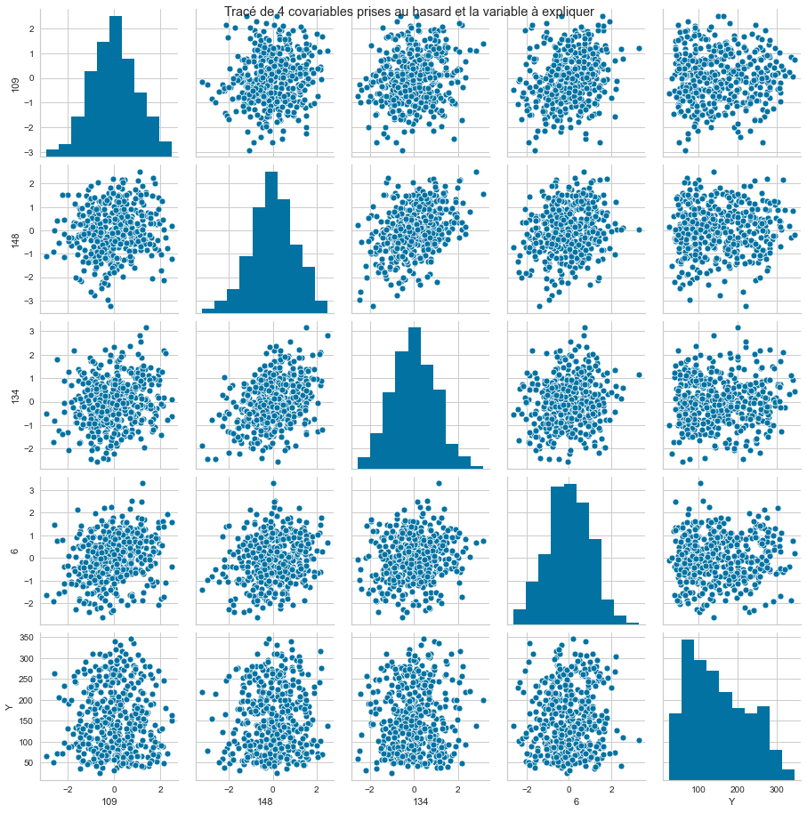

```python
# Tracé du scatterplot

graph_1 = sns.pairplot(df_sample)
graph_1.fig.suptitle("Tracé de 4 covariables prises au hasard et la variable à expliquer", y=1)
```

#### Bilan

Nous remarquons que les 4 variables explicatives tirées de manière aléatoire, elles ont une distribution cohérente avec le fait quelles sont centrées réduites.

De plus, la variable à expliquer possède aussi un distribution cohérente avec le fait que cette dernière soit ni centrée ni réduite.

#### Question 3

Echantillon d’apprentissage et de test. Créer 2 échantillons : un pour apprendre le modèle $X_{train}$, un pour tester le modèle $X_{test}$. On mettra 25% de la base dans l’échantillon ’test’. Donner les tailles de chacun des 2 échantillons. On notera que le nouvel échantillon de covariables $X_{train}$ n’est pas normalisé. Dans la suite, on fera donc bien attention à inclure l’intercept dans nos régressions. (1 point)

#### Construction du jeu de données d'apprentissage ($X_{train}$, $y_{train}$) et du jeu de données de test ($X_{test}$, $y_{test}$)

```python
X_train, X_test, y_train, y_test = train_test_split(X, Y, test_size=0.25, random_state=42)

print("Taille de X_train = ", X_train.shape)
print("Taille de X_test = ", X_test.shape)
print("Taille de y_train = ", y_train.shape)
print("Taille de y_test = ", y_test.shape)
```

```
Taille de X_train =  (331, 160)
Taille de X_test =  (111, 160)
Taille de y_train =  (331,)
Taille de y_test =  (111,)
```

#### Question 4

Donner la matrice de covariance calculée sur Xtrain. Tracer le graphe de la décroissance des valeurs propres de la matrice de covariance (ou de corrélation). Expliquer pourquoi il est légitime de ne garder que les premières variables de l’ACP. On gardera 20 variables dans la suite. (1.5 point)

#### On calcul la matrice de covriance de $X_{train}$

```python
cov_X_train = X_train.cov()
cov_X_train
```

|  | 0 | 1 | 2 | 3 | 4 | 5 | 6 | 7 | 8 | 9 | ... | 150 | 151 | 152 | 153 | 154 | 155 | 156 | 157 | 158 | 159 |
| --- | --- | --- | --- | --- | --- | --- | --- | --- | --- | --- | --- | --- | --- | --- | --- | --- | --- | --- | --- | --- | --- |
| 0 | 0.961657 | 0.253011 | -0.015077 | 0.251007 | 0.068125 | -0.095280 | 0.044595 | 0.225686 | -0.110741 | -0.077449 | ... | -0.029234 | 0.177900 | 0.209244 | 0.105333 | -0.057258 | 0.141210 | 0.267796 | -0.131405 | -0.005937 | -0.059799 |
| 1 | 0.253011 | 1.022872 | 0.215043 | -0.227899 | 0.052896 | 0.154617 | 0.186019 | -0.016937 | -0.172099 | 0.046953 | ... | -0.021087 | 0.137320 | 0.193319 | 0.006402 | -0.001379 | 0.122541 | 0.182017 | 0.133346 | 0.176500 | -0.132567 |
| 2 | -0.015077 | 0.215043 | 1.033553 | -0.173711 | 0.258822 | 0.364627 | -0.324028 | 0.036289 | -0.241677 | -0.302982 | ... | 0.082428 | -0.242740 | -0.049636 | 0.358790 | 0.016514 | 0.018648 | 0.123036 | 0.211552 | 0.010410 | 0.384374 |
| 3 | 0.251007 | -0.227899 | -0.173711 | 0.959350 | 0.090098 | -0.247825 | 0.099694 | 0.454786 | 0.064758 | -0.190026 | ... | -0.274124 | -0.194366 | 0.200930 | -0.294233 | -0.067630 | 0.274825 | 0.062792 | 0.099647 | -0.134493 | 0.004871 |
| 4 | 0.068125 | 0.052896 | 0.258822 | 0.090098 | 0.962612 | -0.199697 | -0.095873 | -0.373503 | -0.381292 | -0.035589 | ... | -0.058659 | -0.208808 | 0.343938 | 0.099409 | -0.074077 | 0.067462 | -0.040522 | 0.093779 | 0.093410 | 0.205457 |
| ... | ... | ... | ... | ... | ... | ... | ... | ... | ... | ... | ... | ... | ... | ... | ... | ... | ... | ... | ... | ... | ... |
| 155 | 0.141210 | 0.122541 | 0.018648 | 0.274825 | 0.067462 | -0.096090 | 0.258265 | 0.094585 | 0.185661 | -0.180136 | ... | -0.021101 | 0.113208 | 0.216956 | 0.440479 | -0.116120 | 0.952691 | -0.037138 | -0.017441 | 0.035689 | -0.167850 |
| 156 | 0.267796 | 0.182017 | 0.123036 | 0.062792 | -0.040522 | -0.118185 | -0.017672 | -0.011559 | 0.148672 | -0.131199 | ... | 0.090294 | -0.277274 | -0.048156 | 0.017166 | -0.028730 | -0.037138 | 0.942248 | 0.022037 | 0.037868 | -0.117109 |
| 157 | -0.131405 | 0.133346 | 0.211552 | 0.099647 | 0.093779 | 0.013171 | 0.186720 | 0.218210 | -0.192099 | 0.174583 | ... | -0.593616 | -0.342547 | -0.098730 | -0.006056 | -0.012780 | -0.017441 | 0.022037 | 1.022716 | 0.047724 | -0.048631 |
| 158 | -0.005937 | 0.176500 | 0.010410 | -0.134493 | 0.093410 | -0.079779 | 0.129770 | 0.290473 | -0.530963 | 0.038436 | ... | 0.175255 | -0.088669 | -0.205483 | 0.238103 | -0.090784 | 0.035689 | 0.037868 | 0.047724 | 1.018895 | 0.029370 |
| 159 | -0.059799 | -0.132567 | 0.384374 | 0.004871 | 0.205457 | 0.083355 | -0.579104 | 0.041178 | -0.455359 | 0.115717 | ... | 0.028822 | 0.027486 | 0.088515 | 0.014246 | 0.033232 | -0.167850 | -0.117109 | -0.048631 | 0.029370 | 1.000217 |

160 rows × 160 columns

#### On trace le graphe de la décroissance des valeurs propres de la matrice de coviance $Cov(X_{train})$

```python
valeur_propre, vecteur_propre = lng.eig(cov_X_train)
print(valeur_propre)
print(vecteur_propre)
```

```
[ 1.00034957e+01+0.00000000e+00j  9.69918289e+00+0.00000000e+00j
  9.16984045e+00+0.00000000e+00j  9.04042338e+00+0.00000000e+00j
  8.85680144e+00+0.00000000e+00j  5.30390631e+00+0.00000000e+00j
  8.45908751e+00+0.00000000e+00j  7.98185051e+00+0.00000000e+00j
  8.16878820e+00+0.00000000e+00j  8.40251551e+00+0.00000000e+00j
  5.70092967e+00+0.00000000e+00j  5.83364901e+00+0.00000000e+00j
  7.77732216e+00+0.00000000e+00j  7.51156947e+00+0.00000000e+00j
  7.09093770e+00+0.00000000e+00j  6.66342466e+00+0.00000000e+00j
  6.92428334e+00+0.00000000e+00j  6.33698337e+00+0.00000000e+00j
  6.26251552e+00+0.00000000e+00j  7.39704061e+00+0.00000000e+00j
  1.37494776e+00+0.00000000e+00j  1.15521624e+00+0.00000000e+00j
  3.35518706e+00+0.00000000e+00j  9.39710940e-01+0.00000000e+00j
  6.06160023e-01+0.00000000e+00j  5.56172645e-01+0.00000000e+00j
  4.78925240e-01+0.00000000e+00j  4.13353650e-01+0.00000000e+00j
  7.35995285e-02+0.00000000e+00j  9.17896412e-03+0.00000000e+00j
 -3.24459627e-15+0.00000000e+00j -2.78984375e-15+2.64663116e-16j
 -2.78984375e-15-2.64663116e-16j -2.63313653e-15+0.00000000e+00j
 -2.39757572e-15+8.49528907e-17j -2.39757572e-15-8.49528907e-17j
 -2.29286785e-15+2.71285995e-16j -2.29286785e-15-2.71285995e-16j
 -2.11588891e-15+2.17819084e-16j -2.11588891e-15-2.17819084e-16j
  2.81878111e-15+0.00000000e+00j  2.73418622e-15+0.00000000e+00j
  2.18839439e-15+6.20788747e-16j  2.18839439e-15-6.20788747e-16j
  2.44423205e-15+3.22219590e-16j  2.44423205e-15-3.22219590e-16j
  2.39522954e-15+1.47541905e-16j  2.39522954e-15-1.47541905e-16j
  2.32022437e-15+1.99804822e-16j  2.32022437e-15-1.99804822e-16j
  2.37811487e-15+0.00000000e+00j -2.00670559e-15+0.00000000e+00j
 -1.88891171e-15+2.16103030e-16j -1.88891171e-15-2.16103030e-16j
  2.13961901e-15+0.00000000e+00j  2.01402195e-15+1.25908272e-16j
  2.01402195e-15-1.25908272e-16j -1.84655075e-15+2.53138666e-16j
 -1.84655075e-15-2.53138666e-16j  1.99312485e-15+8.57361044e-17j
  1.99312485e-15-8.57361044e-17j -1.47820788e-15+6.99023358e-16j
 -1.47820788e-15-6.99023358e-16j -1.63168285e-15+4.80230899e-16j
 -1.63168285e-15-4.80230899e-16j -1.78646113e-15+0.00000000e+00j
  1.60440661e-15+5.66002393e-16j  1.60440661e-15-5.66002393e-16j
  1.89632719e-15+2.43827016e-17j  1.89632719e-15-2.43827016e-17j
  1.72450039e-15+2.09988781e-16j  1.72450039e-15-2.09988781e-16j
 -1.61825297e-15+7.24737152e-17j -1.61825297e-15-7.24737152e-17j
  8.66732599e-16+9.55552782e-16j  8.66732599e-16-9.55552782e-16j
 -1.12601905e-15+6.69562486e-16j -1.12601905e-15-6.69562486e-16j
 -9.54540564e-16+7.59805305e-16j -9.54540564e-16-7.59805305e-16j
```

[output cut: 44 more lines]

```
   1.50953470e-01+0.j         ...  4.58897600e-02+0.j
   4.29818009e-02+0.03593933j  4.29818009e-02-0.03593933j]
 [ 4.53800705e-02+0.j         -7.14731983e-02+0.j
   1.64712072e-01+0.j         ...  1.86656556e-02+0.j
   1.12954355e-02+0.00935228j  1.12954355e-02-0.00935228j]
 ...
 [ 8.74243430e-02+0.j         -6.71526325e-02+0.j
  -4.54360544e-02+0.j         ... -1.64032202e-04+0.j
   4.87361526e-02-0.05829182j  4.87361526e-02+0.05829182j]
 [ 7.77925749e-02+0.j         -9.24910186e-02+0.j
   6.01778250e-02+0.j         ... -1.16596670e-01+0.j
  -1.72561750e-01-0.05320752j -1.72561750e-01+0.05320752j]
 [-4.98090517e-03+0.j         -1.35246615e-01+0.j
   8.84245024e-02+0.j         ... -7.32781274e-02+0.j
  -8.75772165e-02+0.07345307j -8.75772165e-02-0.07345307j]]
```

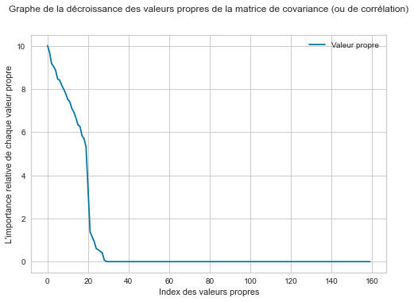

```python
valeur_propre_sorted = sorted(valeur_propre, reverse = True)
plt.plot(valeur_propre_sorted, label="Valeur propre")
plt.ylabel("L'importance relative de chaque valeur propre")
plt.xlabel("Index des valeurs propres")
plt.title("Graphe de la décroissance des valeurs propres de la matrice de covariance (ou de corrélation)\n\n")
plt.legend()
```

```python
description_rate = np.sum(valeur_propre_sorted[0:20]) / np.sum(valeur_propre_sorted)
description_rate.real
```

```
0.9445210862427319
```

#### En faisant le rapport entre les vingts premières valeurs et toutes les autres. Nous remarquons que la partie réel de notre calcul nous permet de conclure que les 20 premières valeurs propres explique 94% du modèle

```python
eigenValues, eigenVectors = lng.eig(cov_X_train)

eigenVectors = eigenVectors.real

idx = eigenValues.argsort()[::-1]
eigenValues = eigenValues[idx]
eigenVectors = eigenVectors[:,idx]
```

```python
eigenValues
```

```
array([ 1.00034957e+01+0.00000000e+00j,  9.69918289e+00+0.00000000e+00j,
        9.16984045e+00+0.00000000e+00j,  9.04042338e+00+0.00000000e+00j,
        8.85680144e+00+0.00000000e+00j,  8.45908751e+00+0.00000000e+00j,
        8.40251551e+00+0.00000000e+00j,  8.16878820e+00+0.00000000e+00j,
        7.98185051e+00+0.00000000e+00j,  7.77732216e+00+0.00000000e+00j,
        7.51156947e+00+0.00000000e+00j,  7.39704061e+00+0.00000000e+00j,
        7.09093770e+00+0.00000000e+00j,  6.92428334e+00+0.00000000e+00j,
        6.66342466e+00+0.00000000e+00j,  6.33698337e+00+0.00000000e+00j,
        6.26251552e+00+0.00000000e+00j,  5.83364901e+00+0.00000000e+00j,
        5.70092967e+00+0.00000000e+00j,  5.30390631e+00+0.00000000e+00j,
        3.35518706e+00+0.00000000e+00j,  1.37494776e+00+0.00000000e+00j,
        1.15521624e+00+0.00000000e+00j,  9.39710940e-01+0.00000000e+00j,
        6.06160023e-01+0.00000000e+00j,  5.56172645e-01+0.00000000e+00j,
        4.78925240e-01+0.00000000e+00j,  4.13353650e-01+0.00000000e+00j,
        7.35995285e-02+0.00000000e+00j,  9.17896412e-03+0.00000000e+00j,
        2.81878111e-15+0.00000000e+00j,  2.73418622e-15+0.00000000e+00j,
        2.44423205e-15+3.22219590e-16j,  2.44423205e-15-3.22219590e-16j,
        2.39522954e-15+1.47541905e-16j,  2.39522954e-15-1.47541905e-16j,
        2.37811487e-15+0.00000000e+00j,  2.32022437e-15+1.99804822e-16j,
        2.32022437e-15-1.99804822e-16j,  2.18839439e-15+6.20788747e-16j,
        2.18839439e-15-6.20788747e-16j,  2.13961901e-15+0.00000000e+00j,
        2.01402195e-15+1.25908272e-16j,  2.01402195e-15-1.25908272e-16j,
        1.99312485e-15+8.57361044e-17j,  1.99312485e-15-8.57361044e-17j,
        1.89632719e-15+2.43827016e-17j,  1.89632719e-15-2.43827016e-17j,
        1.72450039e-15+2.09988781e-16j,  1.72450039e-15-2.09988781e-16j,
        1.60440661e-15+5.66002393e-16j,  1.60440661e-15-5.66002393e-16j,
        1.57849642e-15+0.00000000e+00j,  1.47262868e-15+1.11213202e-16j,
        1.47262868e-15-1.11213202e-16j,  1.43979682e-15+0.00000000e+00j,
        1.32748532e-15+4.88378570e-16j,  1.32748532e-15-4.88378570e-16j,
        1.22962513e-15+0.00000000e+00j,  1.21025250e-15+2.08232179e-16j,
        1.21025250e-15-2.08232179e-16j,  1.19301782e-15+1.81124817e-16j,
        1.19301782e-15-1.81124817e-16j,  1.16389696e-15+0.00000000e+00j,
        9.93185373e-16+0.00000000e+00j,  9.91024199e-16+3.79819564e-16j,
        9.91024199e-16-3.79819564e-16j,  9.53877779e-16+4.53670688e-16j,
        9.53877779e-16-4.53670688e-16j,  8.66732599e-16+9.55552782e-16j,
        8.66732599e-16-9.55552782e-16j,  7.96762612e-16+2.29330609e-16j,
        7.96762612e-16-2.29330609e-16j,  7.31822996e-16+7.85065957e-17j,
        7.31822996e-16-7.85065957e-17j,  6.75104793e-16+4.51011236e-16j,
        6.75104793e-16-4.51011236e-16j,  5.75090326e-16+1.28472174e-16j,
        5.75090326e-16-1.28472174e-16j,  5.73530071e-16+0.00000000e+00j,
```

[output cut: 25 more lines]

```
       -1.12601905e-15+6.69562486e-16j, -1.12601905e-15-6.69562486e-16j,
       -1.20291586e-15+5.13694713e-16j, -1.20291586e-15-5.13694713e-16j,
       -1.22252819e-15+9.86686488e-17j, -1.22252819e-15-9.86686488e-17j,
       -1.46592640e-15+5.12620070e-17j, -1.46592640e-15-5.12620070e-17j,
       -1.47820788e-15+6.99023358e-16j, -1.47820788e-15-6.99023358e-16j,
       -1.61825297e-15+7.24737152e-17j, -1.61825297e-15-7.24737152e-17j,
       -1.63168285e-15+4.80230899e-16j, -1.63168285e-15-4.80230899e-16j,
       -1.78646113e-15+0.00000000e+00j, -1.84655075e-15+2.53138666e-16j,
       -1.84655075e-15-2.53138666e-16j, -1.88891171e-15+2.16103030e-16j,
       -1.88891171e-15-2.16103030e-16j, -2.00670559e-15+0.00000000e+00j,
       -2.11588891e-15+2.17819084e-16j, -2.11588891e-15-2.17819084e-16j,
       -2.29286785e-15+2.71285995e-16j, -2.29286785e-15-2.71285995e-16j,
       -2.39757572e-15+8.49528907e-17j, -2.39757572e-15-8.49528907e-17j,
       -2.63313653e-15+0.00000000e+00j, -2.78984375e-15+2.64663116e-16j,
       -2.78984375e-15-2.64663116e-16j, -3.24459627e-15+0.00000000e+00j])
```

```python
eigenVectors
```

```
array([[ 0.00535398, -0.00667202,  0.04074833, ...,  0.02135082,
         0.02135082, -0.03528115],
       [-0.0456402 , -0.03353806,  0.15095347, ..., -0.01398092,
        -0.01398092, -0.02395219],
       [ 0.04538007, -0.0714732 ,  0.16471207, ...,  0.25713783,
         0.25713783, -0.39395433],
       ...,
       [ 0.08742434, -0.06715263, -0.04543605, ..., -0.01959943,
        -0.01959943, -0.06332615],
       [ 0.07779257, -0.09249102,  0.06017782, ..., -0.00364543,
        -0.00364543, -0.07325525],
       [-0.00498091, -0.13524661,  0.0884245 , ..., -0.05037985,
        -0.05037985, -0.05996622]])
```

#### On sélectionne les 20 premiers vecteurs propres les plus significatifs

```python
eigenVectors_dataframe = pd.DataFrame(eigenVectors, columns=idx)
V_1_20 = eigenVectors_dataframe.iloc[:,:20]
V_1_20
```

|  | 0 | 1 | 2 | 3 | 4 | 6 | 9 | 8 | 7 | 12 | 13 | 19 | 14 | 16 | 15 | 17 | 18 | 11 | 10 | 5 |
| --- | --- | --- | --- | --- | --- | --- | --- | --- | --- | --- | --- | --- | --- | --- | --- | --- | --- | --- | --- | --- |
| 0 | 0.005354 | -0.006672 | 0.040748 | 0.005573 | -0.058178 | 0.122121 | 0.003703 | -0.027277 | -0.141335 | 0.032158 | -0.109865 | -0.001821 | -0.133301 | 0.019494 | 0.124474 | 0.084673 | 0.012744 | -0.128386 | -0.111475 | -0.122054 |
| 1 | -0.045640 | -0.033538 | 0.150953 | 0.035182 | 0.011187 | 0.197671 | -0.130153 | -0.061960 | 0.073000 | 0.058086 | 0.033156 | -0.026752 | -0.052777 | -0.044181 | 0.025539 | -0.106662 | -0.043421 | -0.044961 | -0.090611 | 0.021987 |
| 2 | 0.045380 | -0.071473 | 0.164712 | 0.038218 | 0.014405 | -0.004889 | -0.050226 | 0.110722 | 0.139667 | -0.085612 | 0.055813 | -0.053263 | 0.048471 | 0.023091 | 0.116257 | 0.166186 | 0.010665 | -0.058703 | -0.027311 | 0.041770 |
| 3 | -0.013113 | 0.033400 | -0.004696 | -0.008737 | 0.042264 | -0.035105 | 0.110006 | -0.026972 | -0.085528 | 0.029318 | 0.100951 | 0.073925 | -0.168254 | -0.086274 | -0.002221 | 0.086863 | 0.216000 | -0.044617 | 0.004092 | -0.068234 |
| 4 | 0.126460 | -0.012273 | -0.021261 | -0.046977 | -0.078514 | 0.144157 | -0.080768 | 0.118666 | 0.075352 | -0.046155 | -0.008168 | 0.059378 | -0.022901 | -0.030802 | -0.022341 | 0.073221 | 0.175555 | 0.069644 | 0.025731 | -0.028606 |
| ... | ... | ... | ... | ... | ... | ... | ... | ... | ... | ... | ... | ... | ... | ... | ... | ... | ... | ... | ... | ... |
| 155 | -0.097934 | 0.037506 | -0.033203 | -0.028171 | 0.018129 | 0.015242 | -0.056606 | 0.131490 | 0.003644 | 0.206218 | 0.029480 | -0.077748 | -0.108599 | -0.094659 | 0.017215 | 0.093610 | 0.046683 | -0.065980 | 0.024036 | 0.043073 |
| 156 | 0.013238 | -0.016134 | 0.033450 | 0.046671 | 0.069467 | 0.075773 | -0.048339 | -0.051173 | -0.067465 | 0.011353 | 0.003654 | 0.167819 | 0.072968 | -0.024753 | -0.078367 | 0.158008 | -0.069188 | -0.191339 | -0.085751 | 0.022242 |
| 157 | 0.087424 | -0.067153 | -0.045436 | -0.110998 | -0.041259 | -0.032569 | -0.007251 | -0.062778 | 0.105669 | -0.002869 | 0.185215 | -0.042959 | 0.028912 | -0.069428 | 0.041086 | -0.040011 | 0.056042 | -0.145378 | -0.152754 | 0.052875 |
| 158 | 0.077793 | -0.092491 | 0.060178 | -0.092518 | 0.146995 | 0.003873 | -0.102718 | 0.050602 | -0.101283 | 0.104312 | -0.029727 | -0.020466 | 0.081344 | -0.004319 | -0.004942 | -0.064519 | 0.040029 | 0.129689 | -0.134334 | -0.018238 |
| 159 | -0.004981 | -0.135247 | 0.088425 | 0.019245 | -0.042125 | -0.012969 | 0.155592 | 0.142580 | 0.087984 | -0.068918 | -0.042334 | 0.011086 | 0.056519 | -0.079086 | -0.039234 | 0.043381 | 0.013256 | 0.073965 | -0.049723 | -0.145016 |

160 rows × 20 columns

#### On sélectionne les 20 premières valeurs de notre jeu de d'entrainement les plus significatifs

```python
selected_20_elt_X_train = X_train.iloc[:,idx[:20]]

selected_20_elt_X_train
```

|  | 0 | 1 | 2 | 3 | 4 | 6 | 9 | 8 | 7 | 12 | 13 | 19 | 14 | 16 | 15 | 17 | 18 | 11 | 10 | 5 |
| --- | --- | --- | --- | --- | --- | --- | --- | --- | --- | --- | --- | --- | --- | --- | --- | --- | --- | --- | --- | --- |
| 16 | -1.164888 | 1.083850 | 1.526886 | -1.513630 | 0.674189 | -0.809598 | -0.126997 | -0.930024 | -0.165635 | -0.757735 | 0.586922 | 1.928596 | 1.218946 | 2.365162 | -0.820495 | 0.309858 | 1.586615 | -0.721654 | 1.237674 | -0.084689 |
| 408 | 1.223357 | -0.230554 | -0.387504 | -0.597399 | 0.254686 | -0.818000 | 1.196748 | -1.293556 | -0.214352 | -0.868754 | 0.848171 | 0.726475 | 0.881672 | 0.772153 | -1.092596 | -1.186854 | 1.180304 | 0.126886 | 1.360508 | -0.225762 |
| 432 | 0.669388 | -1.371960 | -0.434061 | 0.700493 | 1.586579 | -1.550750 | -1.136171 | 1.295336 | -1.596687 | -1.938268 | 2.241496 | 0.950583 | -0.900942 | -1.155005 | -1.360834 | 0.259934 | -0.660810 | -1.701247 | 0.603340 | -0.163626 |
| 316 | 0.277256 | -0.541339 | 1.066526 | 0.193334 | 1.224246 | 0.836907 | -0.394476 | -2.174682 | 0.100558 | -0.477662 | 0.848171 | 0.113139 | 0.076850 | -0.713985 | -1.076937 | -0.541269 | -1.164173 | -0.199364 | 0.515478 | 0.869051 |
| 3 | 0.892292 | -0.494714 | -1.062153 | 0.736429 | -0.118200 | -0.454316 | -0.051751 | 2.679422 | -0.378080 | -0.436808 | -0.196823 | 0.617767 | -1.917118 | 0.296036 | 0.056796 | -0.372831 | 1.263778 | 0.301444 | -0.542526 | -1.078412 |
| ... | ... | ... | ... | ... | ... | ... | ... | ... | ... | ... | ... | ... | ... | ... | ... | ... | ... | ... | ... | ... |
| 106 | 0.461149 | -0.462393 | 0.635238 | 0.702779 | 0.267611 | -0.261759 | -0.068320 | -1.087163 | 1.021805 | 0.173121 | -1.764314 | -0.492338 | 1.586647 | 1.244932 | -1.435740 | -0.451065 | -1.675382 | -0.163995 | 0.118635 | -0.633919 |
| 270 | -1.134283 | -0.983491 | 0.980679 | -0.097851 | -0.497799 | 0.279658 | -0.622314 | -0.661972 | 0.594106 | 1.145479 | 0.325674 | 0.194075 | 0.213942 | 0.596185 | -0.149192 | -1.107125 | 0.320176 | -0.569097 | 0.878898 | 1.658021 |
| 348 | -1.403275 | -0.645150 | 0.418578 | -0.766191 | -1.170261 | 0.934671 | 0.821741 | 0.583911 | 0.133021 | 1.486290 | -0.022657 | -0.730607 | -0.645937 | -0.008084 | 0.581140 | -0.765062 | 0.114794 | -0.107733 | 0.918664 | 2.553528 |
| 435 | -0.082640 | -0.459161 | 1.228014 | -0.940499 | -0.319958 | -0.604043 | 0.558260 | -0.062604 | 0.756397 | 0.368756 | -0.806403 | -0.304505 | 0.209387 | -0.585021 | -0.476488 | -0.687527 | 0.282708 | -0.104399 | 0.204180 | 1.166261 |
| 102 | 0.690546 | 0.085791 | 1.864873 | -0.510314 | -0.067660 | -0.614760 | 0.722340 | -0.203428 | 0.277841 | 0.766230 | -0.022657 | -0.237265 | -0.394316 | -0.885986 | -0.320218 | -2.631668 | -0.433253 | -1.500939 | 2.032517 | 1.765142 |

331 rows × 20 columns

#### Question 5

**Application de l'ACP**

Suivant les observations de la question (Q4), appliquer la méthode de "PCA before OLS" qui consiste à appliquer OLS avec $Y$ et $X_{train}$ $V_{(p1:20)}$, où $V_{(p1:20)}$ contient les vecteurs propres (associés aux 20 plus grandes valeurs propres) de la matrice de covariance. Faire une régression linéaire (avec intercept), puis tracer les valeurs des coefficients (hors intercept). Sur un autre graphique, faire de même avec la méthode des moindres carrés classique.

#### Produit matriciel de $X_{train}V_{(1:20)}^{T}$

```python
M = np.dot(X_train, V_1_20)
M = pd.DataFrame(M)
M
```

|  | 0 | 1 | 2 | 3 | 4 | 5 | 6 | 7 | 8 | 9 | 10 | 11 | 12 | 13 | 14 | 15 | 16 | 17 | 18 | 19 |
| --- | --- | --- | --- | --- | --- | --- | --- | --- | --- | --- | --- | --- | --- | --- | --- | --- | --- | --- | --- | --- |
| 0 | 0.372902 | 0.508706 | 4.618665 | -2.638058 | 0.443644 | -0.785534 | -4.598989 | 2.643355 | 3.762269 | -7.251388 | -0.831927 | -8.058876 | -1.687494 | 0.885132 | -2.043372 | -4.689528 | 1.220516 | -0.408123 | 2.532488 | -1.167422 |
| 1 | 5.898953 | -1.184555 | -1.110928 | -3.162083 | -1.395646 | 0.854498 | 2.854362 | -0.008653 | 0.160272 | -5.009488 | -3.748041 | 0.650537 | -3.713228 | 0.444403 | -1.026011 | -2.623525 | -3.609993 | -3.929389 | -1.959181 | -0.111508 |
| 2 | -6.684590 | 6.656192 | -0.737563 | -1.315281 | -4.981926 | 1.915211 | -0.707939 | 8.224980 | -5.486200 | -4.105616 | -1.614371 | 3.128985 | -3.048551 | 2.483632 | -0.434054 | 2.431544 | 2.136834 | 2.829857 | 0.555542 | 4.302904 |
| 3 | 2.775994 | -6.379268 | -1.119269 | -0.332686 | 1.268852 | -1.246600 | -1.810249 | 4.253334 | 0.124747 | 0.570032 | 1.853972 | 3.950503 | -4.920436 | 4.284239 | 3.225216 | 1.015079 | -1.244543 | 2.697914 | 1.134341 | -0.918124 |
| 4 | -1.836801 | 8.829023 | -1.328823 | -1.810341 | -2.071557 | 0.574218 | -0.363986 | -2.719839 | -2.132439 | -2.321957 | -0.889020 | -0.466770 | -1.491011 | -2.992763 | 0.125001 | 3.652401 | -1.344170 | 1.960137 | -1.846609 | -0.242710 |
| ... | ... | ... | ... | ... | ... | ... | ... | ... | ... | ... | ... | ... | ... | ... | ... | ... | ... | ... | ... | ... |
| 326 | 0.967544 | -4.100891 | 3.372817 | -3.247004 | 4.178598 | -1.220101 | -1.344236 | 5.808652 | -4.279813 | 2.277994 | -0.069886 | 2.234614 | -0.092832 | -0.182703 | -3.471319 | 3.175625 | -0.929214 | -0.648796 | -0.088777 | -1.858813 |
| 327 | 2.273885 | -1.477090 | 0.535675 | 1.707785 | 0.994433 | -6.014784 | -1.101197 | 2.211214 | -0.643762 | -1.693607 | 0.627495 | 0.997206 | 0.579527 | 1.373675 | -0.881560 | -0.579339 | 1.418992 | -1.730528 | -2.247494 | 4.582173 |
| 328 | -1.026147 | 3.906562 | 2.414746 | 2.370758 | -0.716581 | -4.984147 | 0.901482 | 7.458080 | -0.081776 | 6.173534 | 1.058563 | -1.779407 | 3.323101 | 1.518471 | -4.083106 | -0.347708 | -1.126922 | -0.645406 | -3.269096 | 2.617548 |
| 329 | -1.812558 | -0.223108 | 1.185068 | -1.050794 | 0.747377 | -3.393857 | -0.209556 | 2.186324 | 3.963434 | -0.052244 | -4.535221 | -0.607602 | 1.496591 | 2.408471 | 3.772308 | -0.312186 | 0.998218 | -0.991633 | 0.358805 | -0.561921 |
| 330 | -0.663606 | 0.467001 | 2.692745 | -3.069183 | -2.799133 | -0.681873 | 0.886576 | 6.189424 | 0.457307 | -1.313740 | 2.574120 | 1.548240 | 1.441495 | 2.903458 | 2.381205 | 0.362717 | -1.996963 | -4.068186 | -3.607497 | 0.406313 |

331 rows × 20 columns

```python
data = M
data
```

|  | 0 | 1 | 2 | 3 | 4 | 5 | 6 | 7 | 8 | 9 | 10 | 11 | 12 | 13 | 14 | 15 | 16 | 17 | 18 | 19 |
| --- | --- | --- | --- | --- | --- | --- | --- | --- | --- | --- | --- | --- | --- | --- | --- | --- | --- | --- | --- | --- |
| 0 | 0.372902 | 0.508706 | 4.618665 | -2.638058 | 0.443644 | -0.785534 | -4.598989 | 2.643355 | 3.762269 | -7.251388 | -0.831927 | -8.058876 | -1.687494 | 0.885132 | -2.043372 | -4.689528 | 1.220516 | -0.408123 | 2.532488 | -1.167422 |
| 1 | 5.898953 | -1.184555 | -1.110928 | -3.162083 | -1.395646 | 0.854498 | 2.854362 | -0.008653 | 0.160272 | -5.009488 | -3.748041 | 0.650537 | -3.713228 | 0.444403 | -1.026011 | -2.623525 | -3.609993 | -3.929389 | -1.959181 | -0.111508 |
| 2 | -6.684590 | 6.656192 | -0.737563 | -1.315281 | -4.981926 | 1.915211 | -0.707939 | 8.224980 | -5.486200 | -4.105616 | -1.614371 | 3.128985 | -3.048551 | 2.483632 | -0.434054 | 2.431544 | 2.136834 | 2.829857 | 0.555542 | 4.302904 |
| 3 | 2.775994 | -6.379268 | -1.119269 | -0.332686 | 1.268852 | -1.246600 | -1.810249 | 4.253334 | 0.124747 | 0.570032 | 1.853972 | 3.950503 | -4.920436 | 4.284239 | 3.225216 | 1.015079 | -1.244543 | 2.697914 | 1.134341 | -0.918124 |
| 4 | -1.836801 | 8.829023 | -1.328823 | -1.810341 | -2.071557 | 0.574218 | -0.363986 | -2.719839 | -2.132439 | -2.321957 | -0.889020 | -0.466770 | -1.491011 | -2.992763 | 0.125001 | 3.652401 | -1.344170 | 1.960137 | -1.846609 | -0.242710 |
| ... | ... | ... | ... | ... | ... | ... | ... | ... | ... | ... | ... | ... | ... | ... | ... | ... | ... | ... | ... | ... |
| 326 | 0.967544 | -4.100891 | 3.372817 | -3.247004 | 4.178598 | -1.220101 | -1.344236 | 5.808652 | -4.279813 | 2.277994 | -0.069886 | 2.234614 | -0.092832 | -0.182703 | -3.471319 | 3.175625 | -0.929214 | -0.648796 | -0.088777 | -1.858813 |
| 327 | 2.273885 | -1.477090 | 0.535675 | 1.707785 | 0.994433 | -6.014784 | -1.101197 | 2.211214 | -0.643762 | -1.693607 | 0.627495 | 0.997206 | 0.579527 | 1.373675 | -0.881560 | -0.579339 | 1.418992 | -1.730528 | -2.247494 | 4.582173 |
| 328 | -1.026147 | 3.906562 | 2.414746 | 2.370758 | -0.716581 | -4.984147 | 0.901482 | 7.458080 | -0.081776 | 6.173534 | 1.058563 | -1.779407 | 3.323101 | 1.518471 | -4.083106 | -0.347708 | -1.126922 | -0.645406 | -3.269096 | 2.617548 |
| 329 | -1.812558 | -0.223108 | 1.185068 | -1.050794 | 0.747377 | -3.393857 | -0.209556 | 2.186324 | 3.963434 | -0.052244 | -4.535221 | -0.607602 | 1.496591 | 2.408471 | 3.772308 | -0.312186 | 0.998218 | -0.991633 | 0.358805 | -0.561921 |
| 330 | -0.663606 | 0.467001 | 2.692745 | -3.069183 | -2.799133 | -0.681873 | 0.886576 | 6.189424 | 0.457307 | -1.313740 | 2.574120 | 1.548240 | 1.441495 | 2.903458 | 2.381205 | 0.362717 | -1.996963 | -4.068186 | -3.607497 | 0.406313 |

331 rows × 20 columns

#### On sélectionne les variables pour la regression linéraire

#### On applique la regression linéaire sur la sélection de nos 20 variables (i.e avec/après ACP)

**Cas 1 : Avec Intercept**

```
[-2.09716654 -0.75545952  2.33745246  0.87240797 -4.60199328 -2.35374581
  0.85591441 -4.5100902  -2.02857023 -1.55319264  2.66930111  0.9302829
 -0.38722384 -0.87599193 -1.35740454 -3.35419948  1.33196941 -3.00091357
 -4.65584463  0.31346   ]
```

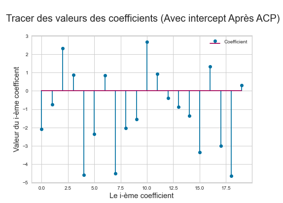

```python
X_data_ = data

regr_regression_avec_intercept = linear_model.LinearRegression(fit_intercept=True)
regr_regression_avec_intercept.fit(X_data_, y_train)

coef_regression_avec_intercept = regr_regression_avec_intercept.coef_

regr_coef_avec_intercept = regr_regression_avec_intercept.intercept_

print(coef_regression_avec_intercept)


plt.title("\n Tracer des valeurs des coefficients (Avec intercept Après ACP)\n", fontsize = 20)
plt.xlabel("Le i-ème coefficient", fontsize = 15)
plt.ylabel("Valeur du i-ème coefficent", fontsize = 15)
plt.stem(coef_regression_avec_intercept, label="Coefficient")
plt.legend()
```

#### On applique une regression linéaire sans intercept et on Trace la valeur des coefficients

**Cas 2 : Sans Intercept**

```
[-2.3561648  -0.61535711  3.966114    0.55103019 -4.23346555 -4.26194431
  1.49191614 -2.13346887 -1.97389703 -0.45978624  6.35206719  1.93134116
 -1.78994591 -0.39882974  0.19289799 -2.5733083   0.06177046 -2.08067443
 -7.78548308 -4.9103573 ]
```

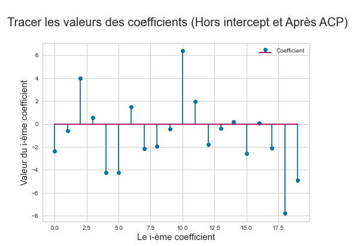

```python
X_data_ = data

regr_sans_intercept = linear_model.LinearRegression(fit_intercept=False)
regr_sans_intercept.fit(X_data_, y_train)

coef_regression_sans_intercept = regr_sans_intercept.coef_

regr_coef_sans_intercept = regr_sans_intercept.intercept_

print(coef_regression_sans_intercept)

plt.title("\n Tracer les valeurs des coefficients (Hors intercept et Après ACP)\n", fontsize = 20)
plt.xlabel("Le i-ème coefficient", fontsize = 15)
plt.ylabel("Valeur du i-ème coefficient", fontsize = 15)
plt.stem(coef_regression_sans_intercept, label="Coefficient")
plt.legend()
```

### On applique la regression linéaire sur l'entièreté de notre jeu de données (i.e sans/avant ACP)

**Cas 1 : Avec Intercept**

```
[-8.36697997e+10  1.36104511e+15 -9.59217607e+14 -7.53963068e+14
  2.40893941e+15  3.11332732e+14 -3.19367990e+13 -5.89255886e+13
  2.09858978e+14 -9.41988052e+14  5.54307032e+14 -7.43340123e+14
 -5.78159370e+14  1.25000000e+00 -8.31796675e+14  9.87327717e+13
  2.22505247e+15  3.16412240e+14 -1.19106103e+15 -6.89252295e+14
  2.70839322e+15  1.43929272e+15 -5.38085938e-01  2.28125000e+01
 -1.69773348e+14  6.07909429e+14 -7.29078769e+14  1.00644509e+15
 -2.80318147e+15 -9.85350207e+14  6.22708652e+14 -3.97815815e+14
  2.08020040e+15 -1.53168782e+15 -5.40786601e+14 -5.79064468e+14
  8.50947532e+14 -7.68128974e+14  9.22043051e+14  5.14985023e+14
 -9.52178574e+14 -1.34486657e+15 -3.20269177e+14  1.06948015e+15
  3.66121542e+14  1.87200918e+13  1.98701899e+14  1.70120185e+13
  9.33887106e+14  5.27744862e+14 -1.43244590e+15 -9.86605861e+14
  1.69666962e+14  1.32747762e+15 -4.75492047e+13  7.58115491e+14
 -2.48077381e+14  6.93030418e+14  1.46680937e+15 -1.26899865e+14
 -9.76948690e+14  1.01764859e+14  1.78369059e+15  5.07850898e+14
 -2.91502250e+14 -3.42791405e+14  3.88423191e+14  1.10601025e+15
  8.26838034e+14  5.60081341e+14  3.27392551e+14  2.89211737e+14
 -8.81684293e+13  1.76875000e+01 -1.05552662e+15 -2.00841314e+14
 -4.84489688e+14 -7.64707885e+14  6.65052398e+14  1.76250000e+01
  8.29339189e+14 -9.02198081e+13 -1.36875000e+01 -6.30651911e+14
 -1.66601416e+14  3.69326286e+14 -1.17104860e+15  2.63130239e+14
 -1.36929094e+14 -1.28654896e+15 -4.79892422e+14 -5.75618335e+13
  9.13029238e+13  1.20550660e+15  7.52927224e+14  7.14984790e+14
 -1.35182706e+15 -1.03831800e+15  4.33671399e+14 -5.01917946e+13
 -7.27690522e+14 -2.31245923e+14 -3.83671042e+13 -1.15086608e+15
  1.02717993e+15 -1.11501394e+15  5.22129172e+14 -9.22375747e+14
 -6.13028480e+14  3.54895321e+14  5.85054540e+14  3.98457978e+14
 -3.72970643e+14 -3.09980526e+14 -2.65544842e+14  5.87500000e+00
  5.19398827e+14  6.03447992e+14 -3.11259528e+14  3.50450370e+14
  4.49184287e+14  3.98004206e+13  3.10937500e+01  2.76750167e+14
  2.72077463e+14 -1.12780475e+15 -9.35017580e+14  6.55890630e+13
  2.65686213e+14  4.78092841e+14  1.63537974e+15 -1.83649527e+15
  1.87500000e+01 -9.30252140e+14 -1.04028628e+14 -2.73650482e+14
  5.82183608e+14 -7.28014812e+14 -3.89637187e+14  1.26789579e+15
  1.44109715e+15  1.44700410e+15 -1.36758378e+15  1.00730911e+15
  9.46056049e+14  2.32249599e+14 -4.57186874e+14 -6.70608605e+14
 -2.75963146e+14 -6.93938481e+14 -1.68897207e+15 -1.44944805e+14
  1.13942360e+15  3.19934476e+13 -3.68750000e+01  1.38496813e+15
 -4.65038889e+14 -6.12063935e+14  6.70445086e+12 -6.37215095e+14]
```

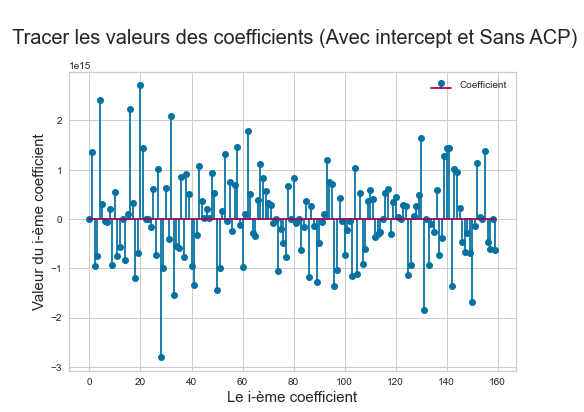

```python
regr_avec_intercept_2 = linear_model.LinearRegression(fit_intercept=True)
regr_avec_intercept_2.fit(X_train, y_train)

coef_regression_avec_intercept_2 = regr_avec_intercept_2.coef_

regr_coef_avec_intercept_2 = regr_avec_intercept_2.intercept_

print(coef_regression_avec_intercept_2)

plt.title("\n Tracer les valeurs des coefficients (Avec intercept et Sans ACP)\n", fontsize = 20)
plt.xlabel("Le i-ème coefficient", fontsize = 15)
plt.ylabel("Valeur du i-ème coefficient", fontsize = 15)
plt.stem(coef_regression_avec_intercept_2, label="Coefficient")
plt.legend()
```

#### Tracé des valeurs des coefficients

**Cas 2 : Sans Intercept**

```
[ 5.28180999e+11  1.71404123e+15 -1.08435540e+15  1.28527280e+15
  1.25602856e+15  1.71954386e+15  2.72546121e+14  3.91575377e+15
 -3.76074561e+15  2.58153130e+15 -1.04147699e+15 -1.30922803e+15
  6.19023082e+15  1.98125000e+01 -3.67498475e+15  4.44986123e+14
  2.20714331e+15  5.96439857e+15 -1.38995074e+15 -3.28727333e+15
  1.64606216e+15 -2.66532162e+15  1.22500000e+01  3.28750000e+01
 -1.37309193e+16 -3.40741578e+13 -8.95490133e+15  5.60988312e+15
  8.52910655e+15 -4.25989342e+15  5.86197866e+15 -7.90247654e+15
  3.00822032e+15  2.42454575e+14 -1.71836745e+15 -1.71404599e+15
  1.31173368e+15  1.32971092e+15  4.18436457e+15  3.74680421e+15
  1.09118708e+15 -7.13625033e+14 -1.20623706e+15  1.40938384e+14
 -1.12794166e+15 -4.70585853e+14 -2.12430201e+15  5.79715617e+14
  2.91626133e+15  1.09420189e+15  2.66936757e+15 -3.38300703e+15
 -7.65635161e+15 -3.68997124e+15 -6.11681246e+15 -1.71769430e+15
 -4.26695683e+15 -3.78571556e+14  1.00990806e+15  4.79825812e+15
 -2.79496301e+14 -3.44168804e+15 -1.49417403e+15 -2.76850832e+15
 -9.16426541e+14 -4.48778766e+15 -1.93065159e+15 -2.26267618e+15
  5.15495706e+15 -4.20660743e+14 -1.82950748e+15  1.38401522e+15
  8.75339758e+14 -4.25000000e+00  8.63491953e+14  2.76310805e+14
  6.39317599e+15  3.14852489e+15 -4.26827592e+15 -4.25000000e+00
  9.02667446e+14 -4.14912830e+15 -1.25000000e+01 -6.38665272e+15
  5.92888942e+14 -5.15685653e+15 -4.24597053e+15  9.78077313e+14
 -1.35146533e+15  1.44112736e+15 -2.38321323e+15 -9.38023933e+14
  1.55416097e+15  3.46656529e+15  3.50475621e+14  2.11774417e+15
  1.88643668e+15 -2.25198166e+15 -1.91815975e+15  5.64154139e+15
 -2.03789798e+15 -2.01022701e+15  5.84712331e+15  1.48939404e+15
  1.96144013e+15  3.17188544e+15  2.49594542e+15 -6.18883653e+15
  1.56455061e+15  4.23685917e+15  3.94082760e+15  1.44580843e+15
  3.02824119e+15 -1.82513498e+15  3.86958272e+15 -4.87500000e+00
  1.25261599e+15 -4.19522707e+15 -2.00063009e+15  2.48759626e+15
 -9.30516250e+14 -3.11599881e+15  2.42500000e+01 -2.97766147e+15
  4.32746437e+15  1.13634646e+15 -4.15162843e+15  1.39737941e+14
 -1.44854531e+14  2.43721236e+15 -3.99969689e+15  3.38039054e+15
  1.68750000e+01 -6.51805436e+13 -5.36736376e+15  3.59842851e+15
  3.95558516e+14 -2.83900451e+15 -1.88817339e+15  3.49678039e+15
 -9.83644702e+14 -2.09875987e+15 -2.53693972e+15  1.47895098e+15
 -4.25508128e+15 -2.06506137e+15 -5.71059563e+15  3.12177485e+15
 -4.36349636e+15  5.25505209e+15  1.89069173e+14  1.56514838e+15
 -3.06110982e+15  2.56975617e+14 -1.13750000e+01  3.63157429e+15
  4.82340137e+15  4.46605615e+14 -1.49846024e+15 -7.87757099e+14]
```

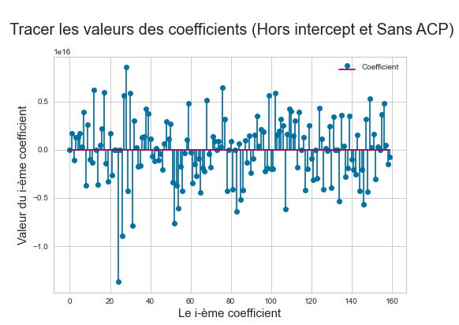

```python
regr_regression_sans_intercept_2 = linear_model.LinearRegression(fit_intercept=False)
regr_regression_sans_intercept_2.fit(X_train, y_train)

coef_regression_sans_intercept_2 = regr_regression_sans_intercept_2.coef_

regr_coef_sans_intercept_2 = regr_regression_sans_intercept_2.intercept_

print(coef_regression_sans_intercept_2)

plt.title("\n Tracer les valeurs des coefficients (Hors intercept et Sans ACP)\n", fontsize = 20)
plt.xlabel("Le i-ème coefficient", fontsize = 15)
plt.ylabel("Valeur du i-ème coefficient", fontsize = 15)
plt.stem(coef_regression_sans_intercept_2, label="Coefficient")
plt.legend()
```

#### Question 6

Donner les valeurs des intercepts pour les 2 régressions précédentes.

**Valeur de l'intercept avant ACP**

```python
regr_coef_avec_intercept_2
```

```
151.99675462613294
```

**Valeur de l'intercept après ACP**

```python
regr_coef_avec_intercept
```

```
153.93829532306054
```

#### Conclusion : Les 2 intercepts ne sont pas égaux car nous avons appliqué une ACP sur l'une des deux regression

#### On donne la valeur moyenne de la variable Y

```python
Y_train_set_mean = y_train.mean()
Y_train_set_mean
```

```
154.34441087613294
```

#### On centre-réduit nos valeurs après ACP

#### On applique une regression linéaire sur les valeurs centrées-réduites après ACP

```python
X_data_ = data
sc = StandardScaler()
X_centered_reduced = sc.fit_transform(X_data_)
X_centered_reduced
```

```
array([[ 0.12350431,  0.16070034,  1.49488083, ..., -0.18394862,
         1.1117451 , -0.42800959],
       [ 1.87333506, -0.38381899, -0.40007856, ..., -1.64405938,
        -0.77230261,  0.03117556],
       [-2.11125872,  2.13761088, -0.27659465, ...,  1.15869589,
         0.28250766,  1.95086933],
       ...,
       [-0.31950612,  1.25338394,  0.76597453, ..., -0.28233946,
        -1.32175159,  1.21795927],
       [-0.5685241 , -0.07463665,  0.35928078, ..., -0.42590393,
         0.19998533, -0.16469527],
       [-0.20470705,  0.14728895,  0.85791777, ..., -1.70161188,
        -1.4636951 ,  0.25636034]])
```

```python
regr_centered_reduced = linear_model.LinearRegression(fit_intercept=True)
regr_centered_reduced.fit(X_centered_reduced, y_train)
regr_coef_intercept_centered_reduced = regr_centered_reduced.intercept_
regr_coef_intercept_centered_reduced
```

```
154.34441087613294
```

#### Conclusion : En centrant et réduisant, on retrouve bien un intercept égale à la valeur moyenne de Y sur le jeu de données d'entrainement

#### Question 7

Pour les 2 méthodes (OLS et PCA before OLS) : Tracer les résidus de la prédiction sur l’échantillon test. Tracer leur densité (on pourra par exemple utiliser un histogramme). Calculer le coefficient de détermination sur l’échantillon test. Calculer le risque de prédiction sur l’échantillon test.

```python
X_test_20 = X_test.iloc[:,idx[0:20]]

X_test_20
```

|  | 0 | 1 | 2 | 3 | 4 | 6 | 9 | 8 | 7 | 12 | 13 | 19 | 14 | 16 | 15 | 17 | 18 | 11 | 10 | 5 |
| --- | --- | --- | --- | --- | --- | --- | --- | --- | --- | --- | --- | --- | --- | --- | --- | --- | --- | --- | --- | --- |
| 287 | -0.201828 | 0.281932 | 1.610011 | -0.031047 | 2.150748 | -1.069920 | -0.415496 | -1.113574 | -0.097640 | -0.199170 | -0.109740 | 0.856770 | -0.459358 | -0.681690 | 0.151312 | -0.056502 | 0.788911 | 0.311887 | 0.680839 | -0.625255 |
| 211 | -1.805484 | -0.257957 | -0.547672 | -1.079767 | -0.298180 | -0.960349 | -0.038900 | 0.267083 | -1.073268 | -0.809189 | -0.458071 | 1.497556 | 0.436957 | 0.447673 | 0.075039 | 0.973074 | 0.713229 | 0.046009 | 1.385243 | 0.243369 |
| 72 | 0.774225 | 0.422045 | -1.106167 | -0.139869 | 2.086120 | 0.960537 | 0.941583 | -1.272711 | -0.121236 | -0.917416 | -0.370989 | 1.932019 | 3.056471 | 1.656430 | -0.920824 | 0.313995 | -0.625888 | -1.340255 | -1.687828 | -1.291254 |
| 321 | 0.266408 | 0.557237 | 0.621400 | 0.520227 | 0.128626 | 1.988325 | 1.382519 | 0.498087 | 1.001914 | 0.763863 | 1.283585 | 0.361758 | 0.233616 | 0.126358 | -0.058616 | -0.496302 | -0.047376 | -0.161158 | 0.357487 | 0.970296 |
| 73 | -0.069769 | 2.196159 | -0.240097 | -1.386540 | 1.825382 | -1.211026 | 0.563794 | -1.121897 | -1.545924 | 0.569800 | -0.196823 | 2.479479 | 1.079130 | 0.032967 | 2.469222 | -0.436043 | 1.113100 | 0.295816 | -0.355301 | -1.016479 |
| ... | ... | ... | ... | ... | ... | ... | ... | ... | ... | ... | ... | ... | ... | ... | ... | ... | ... | ... | ... | ... |
| 45 | -0.337501 | 0.823464 | 1.504698 | -0.445363 | -1.181809 | -1.061219 | -1.786758 | 0.687225 | 0.651296 | 0.365507 | -1.067651 | 0.872284 | -1.501090 | -0.823764 | 2.651156 | -1.649773 | -0.246593 | 1.219435 | -0.353878 | 0.557639 |
| 153 | 0.121347 | -0.716455 | 0.738947 | -0.098190 | 1.790526 | -1.856268 | 0.778745 | -1.960959 | -0.316646 | -0.962001 | 0.238591 | 0.744444 | 0.141184 | -0.529631 | -1.407818 | -0.877551 | 0.271184 | -0.253400 | 1.824834 | 0.208058 |
| 239 | 0.593694 | 0.100548 | -0.742939 | -0.462282 | -0.634225 | 0.064146 | 0.082656 | 0.643291 | -0.360302 | 0.236723 | 1.022336 | 0.808862 | -1.067190 | -0.322006 | -1.014586 | 0.378593 | 2.196954 | 0.413396 | 0.560726 | 0.054114 |
| 380 | -0.652701 | 0.925115 | -0.527399 | -0.268344 | 1.567185 | -1.057269 | 0.729583 | -1.927362 | -0.411078 | -1.423488 | -0.545154 | 0.969913 | 0.638007 | -1.023345 | -1.723427 | 2.160242 | 1.041953 | 0.953852 | 1.059502 | -1.217493 |
| 278 | 1.543272 | 1.095929 | -0.735098 | 0.244082 | 0.303643 | -0.595447 | -1.265512 | -1.426515 | -0.046527 | -1.577228 | 0.674005 | 1.661992 | 2.827025 | 1.112356 | -1.443721 | 1.829825 | 0.754122 | -0.292147 | -0.610840 | -0.944012 |

111 rows × 20 columns

#### Graphe des résidus de la regression avec intercept (PCA before OLS)

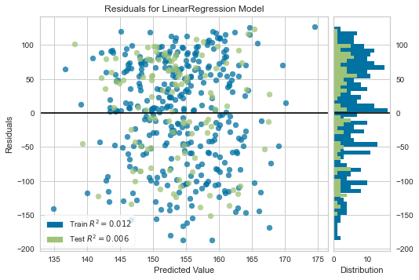

```python
# Instantiate the linear model and visualizer

X_test_20 = X_test.iloc[:,idx[0:20]]

X_train_20 = X_train.iloc[:,idx[0:20]]

visualizer = ResidualsPlot(regr_regression_avec_intercept)

visualizer.fit(X_train_20, y_train)
visualizer.score(X_test_20, y_test)
visualizer.show()
```

**PCA before OLS**

$R_{train}^{2} = 0.012$

$R_{test}^{2} = 0.006$

#### Graphe des résidus de la regression avec intercept (OLS)

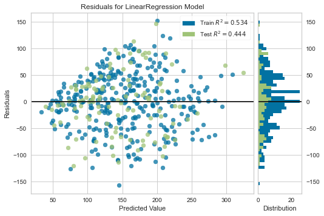

```python
visualizer = ResidualsPlot(regr_avec_intercept_2)

visualizer.fit(X_train, y_train)
visualizer.score(X_test, y_test)
visualizer.show()
```

**OLS sans ACP**

$R_{train}^{2} = 0.534$

$R_{test}^{2} = 0.444$

### Calcul du risque de prédiction sur le jeu de données de test ($X_{test}$) avec sklearn

**OLS sans ACP : Calcul du risque de prédiction**

```python
y_true = y_test
y_pred = regr_avec_intercept_2.predict(X_test)
mean_squared_error(y_true, y_pred)
```

```
3073.5424349926393
```

**PCA before OLS : Calcul du risque de prédiction**

```python
X_test_20 = X_test.iloc[:,idx[0:20]]
y_true = y_test
y_pred = regr_regression_avec_intercept.predict(X_test_20)
mean_squared_error(y_true, y_pred)
```

```
5495.186170846568
```

##### Nous ramrquons que l'on a un MSE plus elevé pour le modèle {ACP avant OLS} que le modèle {OLS sans ACP}

#### Question 8

Coder la méthode de Forward variable sélection. On pourra utiliser la statistique du test de nullité du coefficient (comme vu en cours). Pour l’instant, on ne met pas de critère d’arrêt sur la méthode,c’est-à-dire que l’on ajoute une variable à chaque étape jusqu’à retrouver la totalité des variables.Sachant que le jeu de données initiales ne contenait que les variables [22, 82, 23, 132, 154, 79, 115, 73, 122, 13], combien Forward en a-t-il retrouvé ?

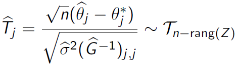

#### Avec comme matrice Gram : $Z^{T}Z/n$

#### Tester la nullité signifie que $\theta_{j}^{*} = 0 $

```python
# fonction qui calcul la statistique de test (t-stat)

def t_stat(coefficient, residus, X_k):
    sigma_chapeau = np.sqrt(((np.linalg.norm(residus))**2) / (len(X_k) - 1))
    result_t_stat = coefficient / (np.sqrt(sigma_chapeau / np.dot(X_k.T, X_k)))
    return result_t_stat
```

#### Les paramètres suivants seront utilisés pour la fonction _forward*selection()*

- Paramètre X = variable explicative (X_i)
- Paramètre Y = variable cible (Y)
- Paramètre k = nombre de variables à sélectionner

```python
# fonction forward selection

# Paramètre X = variable explicative (X_i)
# Paramètre Y = variable cible (Y)
# Paramètre k = nombre de variables à sélectionner

def forward_selection(X, Y, k):
    value_var_selected = list()
    index_value_selected = list()
    Y_pred = Y
    X_scaled = StandardScaler().fit_transform(X)

    # on parcourt la liste des 160 variables explicatives standardisées
    # tant que l'on a pas atteint le nombre de variable à sélectionner
    while (len(value_var_selected) < k):
        max_t_stat = 0 # on initialise le maximum de t_stat à 0
        counter = 0 # on initialise notre compteur de variable à 0
        for X_i in X_scaled.T:
            if counter in index_value_selected:
                counter = counter + 1 # on incrémente notre compteur i
                continue
            Lin_Reg = linear_model.LinearRegression(fit_intercept=False)
            ACP = Lin_Reg.fit(X_i.reshape(-1,1), Y_pred)
            residus = Y_pred - ACP.predict(X_i.reshape(-1,1))
            t_stat_value = t_stat(abs(ACP.coef_[0]), residus, X_i)
            if(t_stat_value > max_t_stat):
                max_t_stat = t_stat_value
                X_i_selected = X_i
                Y_pred = residus
                index = counter
            counter = counter + 1
        value_var_selected.append(X_i_selected)
        index_value_selected.append(index)

    return index_value_selected
```

```python
X_array = X.to_numpy()
Y_array = Y.to_numpy()
nb_features = X.shape[1] # on sélectionne toutes les colonnes du dataset

index_var_selected = forward_selection(X_array, Y_array, nb_features)
print("L'index des variables sélectionnées par la fonction foward_selection() sont :\n", index_var_selected)
```

```
L'index des variables sélectionnées par la fonction foward_selection() sont :
 [23, 122, 13, 132, 26, 82, 147, 79, 115, 73, 96, 112, 137, 120, 68, 154, 71, 90, 4, 148, 124, 46, 141, 107, 59, 81, 80, 126, 14, 39, 118, 84, 35, 145, 101, 11, 50, 105, 22, 47, 61, 62, 31, 104, 43, 41, 92, 113, 127, 5, 138, 88, 53, 119, 86, 130, 157, 97, 27, 12, 140, 69, 110, 123, 83, 150, 111, 121…
```

### On cherche à savoir le nombre de variable trouvé par la fonction forward_selection() par rapport aux variables initiales du jeu de données qui sont :

### [22, 82, 23, 132, 154, 79, 115, 73, 122, 13]

```python
index_var_init = [22, 82, 23, 132, 154, 79, 115, 73, 122, 13]

# On initialise le compteur des index des variables sélectionnées par la fonction
# forward_selection() se trouvant dans la liste contenant les index initiales du dataset
counter_index = 0

# On initialise la liste des index selectionnées par la fonctions
# forward_selection et se trouvant dans la liste contenant les index initiales du dataset
list_index_selected = list()


# On parcourt la liste des index initiales du dataset
for index in index_var_init:
    if index in index_var_selected[0:10]:
        counter_index = counter_index + 1
        list_index_selected.append(index)

print('Le nombre de variables retrouvées est :', counter_index)
print('\nLa liste des index des variables sélectionnées par la fonction forward_selection() se trouvant dans la liste de jeu de données intiales est :\n', list_index_selected)
```

```
Le nombre de variables retrouvées est : 8

La liste des index des variables sélectionnées par la fonction forward_selection() se trouvant dans la liste de jeu de données intiales est :
 [82, 23, 132, 79, 115, 73, 122, 13]
```

#### Question 9

Donner le risque de prédiction obtenu sur l’échantillon test et le comparer à ceux de OLS et PCA before OLS.

```python
feature_selected = [22, 82, 23, 132, 154, 79, 115, 73, 122, 13]

X_train_selected = X_train[feature_selected]
X_test_selected = X_test[feature_selected]

print(X_train_selected)
print(X_test_selected)
```

```
          22        82        23        132       154       79        115  \
16  -0.115937 -0.938537  0.889214  1.038898  0.516642 -0.501640  1.564414
408  1.335088 -0.938537 -1.059520  2.269395  0.661281  0.406893 -0.370637
432  0.189542 -0.938537  1.161130 -0.119218  1.210908  0.940162 -0.061029
316  0.342282  1.065488  0.300062  0.025547  0.024870 -0.448971 -0.680245
3   -1.872441 -0.938537 -0.243771 -0.770658  0.256292  0.525397 -0.757647
..        ...       ...       ...       ...       ...       ...       ...
106 -2.025181 -0.938537 -1.603353 -0.915422 -0.958674 -0.732065  0.171178
270  0.113172  1.065488  0.639957  1.762720 -0.785107 -0.995407  0.325982
348  0.647761 -0.938537 -0.425049 -0.119218 -0.090841 -0.620144  1.641816
435 -0.268676 -0.938537 -0.493028 -0.843040 -0.351191  0.097465 -0.370637
102 -1.948811 -0.938537  0.594638 -0.336364  0.776992  0.525397  1.177404

          73        122       13
16  -0.830301  1.099124  0.586922
```

[output cut: 39 more lines]

#### On applique un OLS sur la variables sélectionnées et on calcul le risque de prédiction (MSE = Mean Squared Error)

```python
regr_feature_selected = linear_model.LinearRegression(fit_intercept=True)
regr_feature_selected.fit(X_train_selected, y_train)

y_true = y_test
y_pred = regr_feature_selected.predict(X_test_selected)
MSE = mean_squared_error(y_true, y_pred)

print("Mean Squared Error =", MSE)
```

```
Mean Squared Error = 2848.295307932944
```

### Question 10 :

Afin de préparer la validation croisée, séparer l’échantillon train en 5 parties (appelées ”folds”) de façon aléatoire. On affichera les numéros d’échantillon sélectionnés dans chaque fold.

#### On applique une cross validation avec la libraire sklearn

```python
X_train_ar = np.array(X_train_selected)
X_train_ar
```

```
array([[-0.11593688, -0.93853666,  0.88921384, ..., -0.83030083,
         1.09912405,  0.58692238],
       [ 1.33508832, -0.93853666, -1.05952046, ...,  0.49631998,
         1.22020278,  0.84817082],
       [ 0.18954211, -0.93853666,  1.16113026, ...,  0.48856196,
         1.17067955,  2.24149579],
       ...,
       [ 0.6477606 , -0.93853666, -0.42504883, ..., -0.83030083,
        -0.22925264, -0.02265729],
       [-0.26867637, -0.93853666, -0.49302793, ..., -0.05449919,
        -0.80855653, -0.80640259],
       [-1.94881082, -0.93853666,  0.59463772, ..., -0.83030083,
        -0.10817391, -0.02265729]])
```

```python
kf = KFold(n_splits=5, shuffle=True, random_state=200)

liste_fold_train, liste_fold_test = list(), list()
i= 1
for train_index, test_index in kf.split(X_train_ar):
    liste_fold_train.append(train_index)
    liste_fold_test.append(test_index)
    print("\n\n--------------- K-Fold " + str(i) + "(index value)" + " ---------------\n")
    print("\nTRAIN = \n", train_index)
    print("\nTEST = \n", test_index)
    i = i + 1

# print(liste_fold_train[0])
# print("-----------------")
# print(liste_fold_test[0])
```

```
--------------- K-Fold 1(index value) ---------------


TRAIN =
 [  0   1   2   3   5   6   7   8   9  10  11  13  14  15  16  17  18  19
  20  21  24  25  26  27  28  29  30  33  34  36  37  38  39  40  42  43
  44  45  46  48  49  50  51  52  53  54  55  56  57  59  60  61  63  64
  65  66  67  69  70  72  74  75  76  77  79  80  81  82  83  84  85  87
  88  89  90  91  93  95  97  98  99 100 102 104 105 106 107 108 109 110
 111 112 113 114 116 117 118 119 123 125 126 128 129 130 131 132 135 136
 137 138 139 140 143 144 145 146 147 149 151 152 154 155 157 158 159 160
 161 162 164 168 169 170 172 173 174 176 177 178 180 181 183 184 185 186
 187 188 189 190 191 192 193 196 197 199 200 201 202 204 205 206 208 210
 212 213 214 215 216 217 218 219 220 221 223 224 225 226 227 228 229 230
 232 233 234 235 236 238 239 240 241 242 243 244 245 246 247 248 249 251
 254 255 256 257 258 259 260 261 262 263 264 268 269 270 271 272 273 275
 276 277 278 279 280 281 282 283 284 285 287 288 289 290 291 292 293 295
 296 297 298 299 300 301 302 303 304 305 306 307 308 309 310 312 314 315
 317 318 319 320 321 322 324 325 326 327 328 330]

TEST =
 [  4  12  22  23  31  32  35  41  47  58  62  68  71  73  78  86  92  94
  96 101 103 115 120 121 122 124 127 133 134 141 142 148 150 153 156 163
 165 166 167 171 175 179 182 194 195 198 203 207 209 211 222 231 237 250
 252 253 265 266 267 274 286 294 311 313 316 323 329]


--------------- K-Fold 2(index value) ---------------


TRAIN =
 [  0   1   2   3   4   6   7  10  12  13  14  15  16  17  21  22  23  24
  25  26  27  28  29  30  31  32  33  35  36  37  38  41  42  43  45  46
  47  48  50  51  52  53  54  55  57  58  59  61  62  63  64  65  67  68
  70  71  73  74  75  76  77  78  79  81  82  83  84  85  86  87  89  90
  92  93  94  95  96  97  99 100 101 102 103 104 105 106 107 108 110 111
 112 113 114 115 116 117 118 120 121 122 123 124 125 126 127 128 129 130
 131 132 133 134 135 136 137 138 139 140 141 142 143 144 145 148 149 150
 151 152 153 154 155 156 157 158 159 160 161 162 163 165 166 167 168 170
 171 173 174 175 176 178 179 180 181 182 183 184 185 186 187 188 189 190
```

[output cut: 78 more lines]

```
 130 132 133 134 136 137 138 140 141 142 144 145 146 147 148 149 150 152
 153 154 155 156 157 158 160 162 163 164 165 166 167 169 170 171 172 174
 175 176 177 179 181 182 188 191 194 195 197 198 199 202 203 204 205 206
 207 208 209 210 211 212 213 214 215 217 220 221 222 223 224 225 226 227
 228 229 230 231 232 233 234 235 236 237 239 240 241 243 245 246 247 248
 249 250 251 252 253 254 256 257 258 259 260 261 262 264 265 266 267 268
 269 270 271 273 274 275 277 280 281 283 284 285 286 287 288 289 290 292
 293 294 295 296 297 299 300 301 302 303 304 305 306 307 309 310 311 313
 314 315 316 317 318 319 320 322 323 325 327 329 330]

TEST =
 [  0   1   3   6   7  14  38  42  51  52  55  76  79  81  82  85  89  97
  99 105 128 129 131 135 139 143 151 159 161 168 173 178 180 183 184 185
 186 187 189 190 192 193 196 200 201 216 218 219 238 242 244 255 263 272
 276 278 279 282 291 298 308 312 321 324 326 328]
```

### Question 11 :

Appliquer la méthode de la régression Ridge. Pour le choix du paramètre de régularisation, on fera une validation croisée sur les ”folds” définis lors de la question précédente. A tour de rôle chacun des ”folds” servira à calculer le risque de prédiction alors que les autres seront utilisés pour estimer le modèle. On moyennera ensuite les 5 risques de prédictions. On donnera la courbe du risque de validation croisée en fonction du paramètre de régularisation (on veillera à bien choisir l’espace de définition pour le graphe). Donner le paramètre de régularisation optimal et la valeur du risque sur le test.

```python
liste_alpha = np.linspace(0.001, 100, num=1000).tolist()

dico_mse_folder = dict()
dico_mse_all = dict()

for i in range(5):
    dico_mse_folder[i + 1] = list()

for i in liste_alpha:
    dico_mse_all[i] = list()

for alpha in liste_alpha:

    for i in range(5):

        X_train_bis = X[feature_selected].iloc[liste_fold_train[i],:]
        y_train_bis = Y.iloc[liste_fold_train[i]]

        X_test_bis = X[feature_selected].iloc[liste_fold_test[i],:]
        y_test_bis = Y.iloc[liste_fold_test[i]]

        rid = Ridge(alpha).fit(X_train_bis, y_train_bis)

        y_true = y_test_bis

        y_pred = rid.predict(X_test_bis)
        mse = mean_squared_error(y_true, y_pred)

        dico_mse_folder[i + 1].append(mse)
        dico_mse_all[alpha].append(mse)

for i in range(5):
    dico_mse_folder[i + 1] = np.mean(dico_mse_folder[i + 1])

for alpha in liste_alpha:
    dico_mse_all[alpha] = np.mean(dico_mse_all[alpha])

print("MSE moyennée pour les 5 folds :\n", dico_mse_folder)
```

```
MSE moyennée pour les 5 folds :
 {1: 2848.3100676378626, 2: 3696.546913382171, 3: 3408.5987634588755, 4: 2707.366139102681, 5: 2954.6285766451797}
```

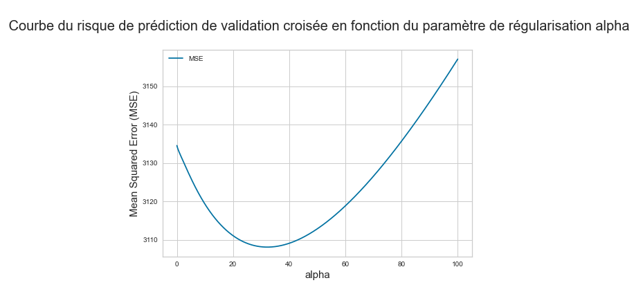

```python
plt.plot(liste_alpha, list(dico_mse_all.values()), label="MSE")
plt.title("\n Courbe du risque de prédiction de validation croisée en fonction du paramètre de régularisation alpha\n", fontsize = 20)
plt.xlabel("alpha", fontsize = 15)
plt.ylabel("Mean Squared Error (MSE)", fontsize = 15)
plt.legend()
plt.show()
```

### Interprétation :

#### Au regard de la courbe du graphe on peut en déduire que le alpha minimal se trouve pas loin de 35.

#### Question 12 :

A l’aide de la fonction lassoCV de sklearn, choisir le paramètre de régularisation du LASSO. Donner le risque de prédiction associé.

On predndra comme paramètre de la fonction lassoCV les paramètres suivants:

- cv = 5 (Cross Valisation : on split le jeu d'entrainement en 5 folds)
- alpha = une liste de valeurs entre 0,01 et 3 par pas de 0,001

```python
alphas = np.arange(0.01,3, 0.001)

lcv = LassoCV(cv=5, random_state=0, alphas=alphas).fit(X_train_selected, y_train)

avg_mse = np.mean(lcv.mse_path_,axis=1)

df_lasso_alpha = pd.DataFrame({'alpha':lcv.alphas_,'MSE':avg_mse})
df_lasso_alpha.head(10)
```

|  | alpha | MSE |
| --- | --- | --- |
| 0 | 2.999 | 3186.799904 |
| 1 | 2.998 | 3186.760921 |
| 2 | 2.997 | 3186.728736 |
| 3 | 2.996 | 3186.698127 |
| 4 | 2.995 | 3186.672269 |
| 5 | 2.994 | 3186.644891 |
| 6 | 2.993 | 3186.620818 |
| 7 | 2.992 | 3186.594548 |
| 8 | 2.991 | 3186.571138 |
| 9 | 2.990 | 3186.545278 |

#### On cherche à connaitre le paramètre $\alpha\$ qui a le plus petit MSE

```python
min_mse_lassoCV = df_lasso_alpha.MSE.min()
df_lasso_alpha[df_lasso_alpha.MSE == min_mse_lassoCV]
```

|  | alpha | MSE |
| --- | --- | --- |
| 2892 | 0.107 | 3140.628218 |

#### $\alpha\ = 0.107 => min(MSE) = 3140.628218$

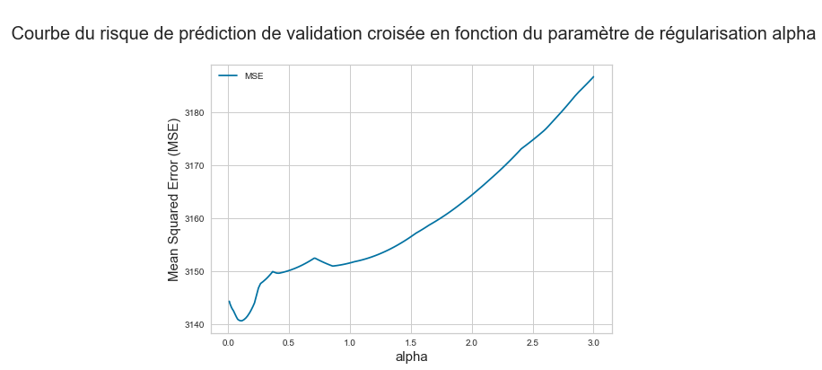

```python
plt.plot(lcv.alphas_,avg_mse, label="MSE")
plt.title("\n Courbe du risque de prédiction de validation croisée en fonction du paramètre de régularisation alpha\n", fontsize = 20)
plt.xlabel("alpha", fontsize = 15)
plt.ylabel("Mean Squared Error (MSE)", fontsize = 15)
plt.legend()
plt.show()
```

#### Question 13 :

Donner les variables selectionées par le Lasso. Combien y en a-t-il ? Appliquer la méthode OLS aux variables sélectionnées. Cette méthode est appelé Least-Square LASSO.

https://towardsdatascience.com/feature-selection-in-machine-learning-using-lasso-regression-7809c7c2771a

```python
import numpy as np
from sklearn.preprocessing import StandardScaler
from sklearn.pipeline import Pipeline
from sklearn.model_selection import train_test_split, GridSearchCV
from sklearn.linear_model import Lasso
```

```python
pipeline = Pipeline([
                     ('scaler',StandardScaler()),
                     ('model',Lasso())
])
```

```python
# On cherche le paramètre alpha optimal

search = GridSearchCV(pipeline,
                      {'model__alpha':np.arange(3,3.3,0.001)},
                      cv = 5, scoring="neg_mean_squared_error",verbose=3
                      )

search.fit(X_train,y_train)
```

[output not shown]

[output not shown]

[output not shown]

[output cut: 2915 more lines]

[output not shown]

```
[Parallel(n_jobs=1)]: Done 1500 out of 1500 | elapsed:   19.9s finished
```

```
GridSearchCV(cv=5,
             estimator=Pipeline(steps=[('scaler', StandardScaler()),
                                       ('model', Lasso())]),
             param_grid={'model__alpha': array([3.   , 3.001, 3.002, 3.003, 3.004, 3.005, 3.006, 3.007, 3.008,
       3.009, 3.01 , 3.011, 3.012, 3.013, 3.014, 3.015, 3.016, 3.017,
       3.018, 3.019, 3.02 , 3.021, 3.022, 3.023, 3.024, 3.025, 3.026,
       3.027, 3.028, 3.029, 3.03 , 3.031, 3.032, 3.033, 3.034, 3.035,
       3.036, 3.037, 3....
       3.243, 3.244, 3.245, 3.246, 3.247, 3.248, 3.249, 3.25 , 3.251,
       3.252, 3.253, 3.254, 3.255, 3.256, 3.257, 3.258, 3.259, 3.26 ,
       3.261, 3.262, 3.263, 3.264, 3.265, 3.266, 3.267, 3.268, 3.269,
       3.27 , 3.271, 3.272, 3.273, 3.274, 3.275, 3.276, 3.277, 3.278,
       3.279, 3.28 , 3.281, 3.282, 3.283, 3.284, 3.285, 3.286, 3.287,
       3.288, 3.289, 3.29 , 3.291, 3.292, 3.293, 3.294, 3.295, 3.296,
       3.297, 3.298, 3.299])},
             scoring='neg_mean_squared_error', verbose=3)
```

```python
best_params = search.best_params_

print("alpha optimal = ", best_params)
```

```
alpha optimal =  {'model__alpha': 3.298999999999967}
```

```python
coefficients = search.best_estimator_.named_steps['model'].coef_
```

```python
importance = np.abs(coefficients)
importance
```

```
array([0.00000000e+00, 0.00000000e+00, 0.00000000e+00, 0.00000000e+00,
       0.00000000e+00, 0.00000000e+00, 0.00000000e+00, 0.00000000e+00,
       0.00000000e+00, 0.00000000e+00, 0.00000000e+00, 0.00000000e+00,
       0.00000000e+00, 0.00000000e+00, 0.00000000e+00, 0.00000000e+00,
       0.00000000e+00, 0.00000000e+00, 0.00000000e+00, 0.00000000e+00,
       0.00000000e+00, 0.00000000e+00, 0.00000000e+00, 2.45516357e+01,
       0.00000000e+00, 0.00000000e+00, 0.00000000e+00, 0.00000000e+00,
       0.00000000e+00, 0.00000000e+00, 0.00000000e+00, 0.00000000e+00,
       0.00000000e+00, 0.00000000e+00, 0.00000000e+00, 0.00000000e+00,
       0.00000000e+00, 0.00000000e+00, 0.00000000e+00, 1.14569566e+00,
       0.00000000e+00, 0.00000000e+00, 0.00000000e+00, 0.00000000e+00,
       0.00000000e+00, 0.00000000e+00, 8.16031958e-03, 0.00000000e+00,
       0.00000000e+00, 0.00000000e+00, 0.00000000e+00, 0.00000000e+00,
       0.00000000e+00, 0.00000000e+00, 0.00000000e+00, 0.00000000e+00,
       0.00000000e+00, 0.00000000e+00, 0.00000000e+00, 0.00000000e+00,
       0.00000000e+00, 0.00000000e+00, 0.00000000e+00, 0.00000000e+00,
       0.00000000e+00, 0.00000000e+00, 0.00000000e+00, 0.00000000e+00,
       0.00000000e+00, 0.00000000e+00, 0.00000000e+00, 1.10100446e+00,
       0.00000000e+00, 0.00000000e+00, 0.00000000e+00, 0.00000000e+00,
       0.00000000e+00, 0.00000000e+00, 0.00000000e+00, 0.00000000e+00,
       0.00000000e+00, 0.00000000e+00, 6.02920440e+00, 0.00000000e+00,
       0.00000000e+00, 0.00000000e+00, 0.00000000e+00, 0.00000000e+00,
       0.00000000e+00, 0.00000000e+00, 0.00000000e+00, 0.00000000e+00,
       0.00000000e+00, 0.00000000e+00, 0.00000000e+00, 5.31866188e-01,
       0.00000000e+00, 0.00000000e+00, 1.82808643e+00, 0.00000000e+00,
       0.00000000e+00, 0.00000000e+00, 0.00000000e+00, 0.00000000e+00,
       0.00000000e+00, 0.00000000e+00, 0.00000000e+00, 0.00000000e+00,
       0.00000000e+00, 0.00000000e+00, 0.00000000e+00, 0.00000000e+00,
       0.00000000e+00, 0.00000000e+00, 0.00000000e+00, 1.18237331e+01,
       0.00000000e+00, 0.00000000e+00, 0.00000000e+00, 3.39993910e-02,
       0.00000000e+00, 0.00000000e+00, 1.86783417e+01, 0.00000000e+00,
       0.00000000e+00, 0.00000000e+00, 0.00000000e+00, 0.00000000e+00,
       0.00000000e+00, 1.43001499e+00, 0.00000000e+00, 0.00000000e+00,
       1.47547898e+01, 0.00000000e+00, 0.00000000e+00, 0.00000000e+00,
       0.00000000e+00, 0.00000000e+00, 0.00000000e+00, 0.00000000e+00,
       0.00000000e+00, 0.00000000e+00, 4.42321012e+00, 0.00000000e+00,
       0.00000000e+00, 0.00000000e+00, 0.00000000e+00, 0.00000000e+00,
       0.00000000e+00, 0.00000000e+00, 0.00000000e+00, 0.00000000e+00,
       0.00000000e+00, 0.00000000e+00, 1.26707990e+00, 0.00000000e+00,
       0.00000000e+00, 1.83451143e+00, 0.00000000e+00, 0.00000000e+00])
```

```python
# Conversion de la variable "importance" en DataFrame
df_importance = pd.DataFrame(importance)
df_importance = df_importance.rename(columns={0: "alpha"})
df_importance
```

|  | alpha |
| --- | --- |
| 0 | 0.000000 |
| 1 | 0.000000 |
| 2 | 0.000000 |
| 3 | 0.000000 |
| 4 | 0.000000 |
| ... | ... |
| 155 | 0.000000 |
| 156 | 0.000000 |
| 157 | 1.834511 |
| 158 | 0.000000 |
| 159 | 0.000000 |

160 rows × 1 columns

```python
# on sélectionne les alphas dont la valeur est strictement supérieur à 0

df_variables_seletionnees_lasso = df_importance.loc[df_importance.alpha > 0].T

liste_variables_seletionnees = df_variables_seletionnees_lasso.columns.tolist()

print("Le nombre de variables selectionnées par LassoCV est \n", len(liste_variables_seletionnees))
print("\nLa liste des variables selectionnées par LassoCV est \n", liste_variables_seletionnees)
```

```
Le nombre de variables selectionnées par LassoCV est
 15

La liste des variables selectionnées par LassoCV est
 [23, 39, 46, 71, 82, 95, 98, 115, 119, 122, 129, 132, 142, 154, 157]
```

#### Appliquons la méthode OLS sur ces variables sélectionné et on calcule le MSE

```python
regr_lsl = linear_model.LinearRegression(fit_intercept = True)
regr_lsl.fit(X_train[liste_variables_seletionnees], y_train)

y_true = y_test
y_pred = regr_lsl.predict(X_test[liste_variables_seletionnees])
mse_error = mean_squared_error(y_true, y_pred)
print("Le risque de prédiction (MSE) = ", mse_error)
```

```
Le risque de prédiction (MSE) =  3037.319914441556
```

#### Question 14:

Les variables initiales du jeu de données sont [22, 82, 23, 132, 154, 79, 115, 73, 122, 13]. Combien le Lasso en a-t-il retrouvé ?

```python
liste_variable_init = [22, 82, 23, 132, 154, 79, 115, 73, 122, 13]

print("La liste des variables intiales du jeu de données est : \n", liste_variable_init)
```

```
La liste des variables intiales du jeu de données est :
 [22, 82, 23, 132, 154, 79, 115, 73, 122, 13]
```

```python
liste_variables_seletionnees
print("La nombre de variables sélectionnées par le modèle LassoCV est :\n", len(liste_variables_seletionnees))
print("La liste des variables sélectionnées par le modèle LassoCV est :\n", liste_variables_seletionnees)
```

```
La nombre de variables sélectionnées par le modèle LassoCV est :
 15
La liste des variables sélectionnées par le modèle LassoCV est :
 [23, 39, 46, 71, 82, 95, 98, 115, 119, 122, 129, 132, 142, 154, 157]
```

```python
conuter_var = 0
for i in liste_variables_seletionnees:
    if i in liste_variable_init:
        conuter_var = conuter_var + 1

print("Le nombre de variables trouvées par le LassoCV qui se trouvent également dans la liste des variables initiales est : ", conuter_var)
```

```
Le nombre de variables trouvées par le LassoCV qui se trouvent également dans la liste des variables initiales est :  6
```